# Business Case: Scaler - Clustering

## Problem Statement

Scaler is an online tech-versity offering intensive computer science & Data Science courses through live classes delivered by tech leaders and subject matter experts. The meticulously structured program enhances the skills of software professionals by offering a modern curriculum with exposure to the latest technologies. It is a product by InterviewBit.

You are working as a data scientist with the analytics vertical of Scaler, focused on profiling the best companies and job positions to work for from the Scaler database. You are provided with the information for a segment of learners and tasked to cluster them on the basis of their job profile, company, and other features. Ideally, these clusters should have similar characteristics.

### Data Dictionary:

- ‘Unnamed 0’- Index of the dataset
- Email_hash- Anonymised Personal Identifiable Information (PII)
- Company_hash- Current employer of the learner
- orgyear- Employment start date
- CTC- Current CTC
- Job_position- Job profile in the company
- CTC_updated_year: Year in which CTC got updated (Yearly increments, Promotions)

### Concept Used:

Manual Clustering Unsupervised Clustering - K- means, Hierarchical Clustering

### Additional views

We will begin by importing data and performing basic data exploration, cleaning, imputation, and data aggregation. We will then create a few new features to allow us to group learners into meaningful logical groups (manual clustering). We will attempt to answer a few business queries using the derived features, and also perform uni-variate/bi-variate analyses on the features. In the last section, we will perform unsupervised clustering using KMeans and hierarchical clustering algorithms. We will begin by pre-processing data to make is suitable for clustering, checking data-sets clustering tendency, using elbow method to determine number of clusters, and finally we will evaluate and visualize clusters. At the end, we will attempt to define characteristics of the identified clusters and report business recommendations.

# Solution

## Basic Data Exploration and Pre-processing

```python
import re
import numpy as np
import pandas as pd

import matplotlib.pyplot as plt
import seaborn as sns
import plotly.express as px

from sklearn.preprocessing import LabelEncoder, OneHotEncoder, StandardScaler
from sklearn.impute import KNNImputer
from sklearn.cluster import KMeans, AgglomerativeClustering
from sklearn.metrics import silhouette_score
from sklearn.decomposition import PCA
from sklearn.manifold import TSNE

from scipy.stats import percentileofscore
from pyclustertend import hopkins

#set seaborn theme
sns.set_theme(style="whitegrid", palette="deep")
```

```python
df = pd.read_csv('scaler_clustering.csv')
df.drop('Unnamed: 0', axis=1, inplace=True)
df.head()
```

|  | company_hash | email_hash | orgyear | ctc | job_position | ctc_updated_year |
| --- | --- | --- | --- | --- | --- | --- |
| 0 | atrgxnnt xzaxv | 6de0a4417d18ab14334c3f43397fc13b30c35149d70c05... | 2016.0 | 1100000 | Other | 2020.0 |
| 1 | qtrxvzwt xzegwgbb rxbxnta | b0aaf1ac138b53cb6e039ba2c3d6604a250d02d5145c10... | 2018.0 | 449999 | FullStack Engineer | 2019.0 |
| 2 | ojzwnvwnxw vx | 4860c670bcd48fb96c02a4b0ae3608ae6fdd98176112e9... | 2015.0 | 2000000 | Backend Engineer | 2020.0 |
| 3 | ngpgutaxv | effdede7a2e7c2af664c8a31d9346385016128d66bbc58... | 2017.0 | 700000 | Backend Engineer | 2019.0 |
| 4 | qxen sqghu | 6ff54e709262f55cb999a1c1db8436cb2055d8f79ab520... | 2017.0 | 1400000 | FullStack Engineer | 2019.0 |

```python
origdf = df.copy()
```

```python
df.info()
```

```
<class 'pandas.core.frame.DataFrame'>
RangeIndex: 205843 entries, 0 to 205842
Data columns (total 6 columns):
 #   Column            Non-Null Count   Dtype
---  ------            --------------   -----
 0   company_hash      205799 non-null  object
 1   email_hash        205843 non-null  object
 2   orgyear           205757 non-null  float64
 3   ctc               205843 non-null  int64
 4   job_position      153281 non-null  object
 5   ctc_updated_year  205843 non-null  float64
dtypes: float64(2), int64(1), object(3)
memory usage: 9.4+ MB
```

```python
#remove duplicate rows if any
df = df.drop_duplicates()
df.shape
```

```
(205810, 6)
```

**Observations:** Total 33 duplicate records removed.

```python
#check missing values
df.isna().agg(['sum', 'mean']).rename({'sum': 'count', 'mean': 'fraction of total'}).T
```

|  | count | fraction of total |
| --- | --- | --- |
| company_hash | 44.0 | 0.000214 |
| email_hash | 0.0 | 0.000000 |
| orgyear | 86.0 | 0.000418 |
| ctc | 0.0 | 0.000000 |
| job_position | 52547.0 | 0.255318 |
| ctc_updated_year | 0.0 | 0.000000 |

```python
df.describe(include='O')
```

|  | company_hash | email_hash | job_position |
| --- | --- | --- | --- |
| count | 205766 | 205810 | 153263 |
| unique | 37299 | 153443 | 1017 |
| top | nvnv wgzohrnvzwj otqcxwto | bbace3cc586400bbc65765bc6a16b77d8913836cfc98b7... | Backend Engineer |
| freq | 8337 | 10 | 43546 |

```python
df.describe()
```

|  | orgyear | ctc | ctc_updated_year |
| --- | --- | --- | --- |
| count | 205724.000000 | 2.058100e+05 | 205810.000000 |
| mean | 2014.882284 | 2.271854e+06 | 2019.628279 |
| std | 63.576199 | 1.180185e+07 | 1.325188 |
| min | 0.000000 | 2.000000e+00 | 2015.000000 |
| 25% | 2013.000000 | 5.300000e+05 | 2019.000000 |
| 50% | 2016.000000 | 9.500000e+05 | 2020.000000 |
| 75% | 2018.000000 | 1.700000e+06 | 2021.000000 |
| max | 20165.000000 | 1.000150e+09 | 2021.000000 |

```python
np.unique(df[~df['orgyear'].isna()]['orgyear'].astype('int'))
```

```
array([    0,     1,     2,     3,     4,     5,     6,    38,    83,
          91,   200,   201,   206,   208,   209,  1900,  1970,  1971,
        1972,  1973,  1976,  1977,  1979,  1981,  1982,  1984,  1985,
        1986,  1987,  1988,  1989,  1990,  1991,  1992,  1993,  1994,
        1995,  1996,  1997,  1998,  1999,  2000,  2001,  2002,  2003,
        2004,  2005,  2006,  2007,  2008,  2009,  2010,  2011,  2012,
        2013,  2014,  2015,  2016,  2017,  2018,  2019,  2020,  2021,
        2022,  2023,  2024,  2025,  2026,  2027,  2028,  2029,  2031,
        2101,  2106,  2107,  2204, 20165])
```

**Observations:**

- We observe that ctc_updated_year ranges from 2015 to 2021. Since the highest ctc updated year is 2021, we can take 2022 as the curryear for all calculations.
- orgyear value seems more inconsistent. it has Nan values, zero values, and some values much higher than possible year values. Needs more examination.

### checking consistency of 'ctc_updated_year'

```python
curryear = 2022
```

```python
#convert ctc_updated_year to int
df['ctc_updated_year'].astype('int')

df['ctc_updated_year'].value_counts()
```

```
2019.0    68665
2021.0    64975
2020.0    49435
2017.0     7561
2018.0     6746
2016.0     5501
2015.0     2927
Name: ctc_updated_year, dtype: int64
```

**observations:** ctc_updated_year value for all records appear in reasonable range. We assume that ctc_updated_year value for each record is accurate. Next, we check the value of 'orgyear'.

### checking consistency of 'orgyear'

We can validate orgyear using the combination of the following rules.

1. Considering 50-52 years as the maximum career span (or at-least likely work experience range of Scaler learners), all records with 'orgyear' < 1971 are potential suspects.
2. It's reasonable to expect 'orgyear' to be less than or equal to 'ctc_updated_year'. All records where (orgyear > cct_updated_year) are error suspects. In the absence any additional data about the nature of the errors, ctc_updated_year provides the best estimate for orgyear. We will simply set orgyear to their ctc_updated_year value.

```python
# 1. For all records with orgyear < 1970, set their orgyear to Nan and impute with KNN later.
mask = df['orgyear'] < 1970
print(df[mask]['orgyear'].value_counts())

#set the orgyear value to Nan for the records above. We will impute them with knn later.
df.loc[mask, 'orgyear'] = np.NAN
```

```
0.0       17
3.0        6
91.0       3
2.0        3
5.0        2
1.0        2
6.0        2
208.0      1
209.0      1
206.0      1
4.0        1
83.0       1
38.0       1
1900.0     1
201.0      1
200.0      1
Name: orgyear, dtype: int64
```

```python
#find all records where orgyear > ctc_updated_year
mask = df['orgyear'] > df['ctc_updated_year']
print(f'impacted records : {df[mask].shape[0]}')

#set orgyear to ctc_updatged_year (which is our best estimate for correct orgyear)
df.loc[mask, 'orgyear'] = df.loc[mask, 'ctc_updated_year']
```

```
impacted records : 8840
```

```python
df.agg({'orgyear': ['min', 'max']})
```

|  | orgyear |
| --- | --- |
| min | 1970.0 |
| max | 2021.0 |

### Analyze email_hash, company_hash, and job_position

```python
#check unique values
for col in ['email_hash', 'company_hash', 'job_position']:
    print(f'unique no of {col}: {df[col].nunique()}')
```

```
unique no of email_hash: 153443
unique no of company_hash: 37299
unique no of job_position: 1017
```

**Observations:**

1. All **email_hash** values appear to share the same formatting and appear to be system generated 64 char values. So we can assume them to be consistent and error free.
2. **company_hash** values, however, appear with inconsistent formatting and length. It is possible that it was generated by masking the actual names using a specific algorithm. Similarly, **job_position**, may have been manually entered by learners (or sourced from disparate data sources) and therefore more likely be inconsistent and error-prone.

In this case-study, we will sanitize all 'job_positions' and 'company_hash' columns by converting to lower case, trimming them, and removing any non-alphanumeric characters.

#### Sanitize job_positions

We can convert job_positions to lower case, trim it, and remove any non-alpha-numeric characters (including whitespace) from it in order to make it more consistent.

```python
def remove_sp_char(x):
    return re.sub(r'[^a-zA-Z0-9]*', '', x) if (type(x) is str) else x

def sanitize_string_col(df, col):
    #convert to lower case and trim
    df[col] = df[col].str.lower().str.strip()

    #remove any special characters and also space
    df[col] = df[col].transform(remove_sp_char)

sanitize_string_col(df, 'job_position')
print(f"no of unique job_positions: {df['job_position'].nunique()}")
```

```
no of unique job_positions: 873
```

```python
jpvc = df['job_position'].value_counts()
jpvc
```

```
backendengineer                  43546
fullstackengineer                25982
other                            18072
frontendengineer                 10418
engineeringleadership             6870
                                 ...
riskinvestigator                     1
x                                    1
machinelearningengineerintern        1
thirdpartyprovider                   1
azuredatafactory                     1
Name: job_position, Length: 873, dtype: int64
```

**Observation:** On careful examination, we notice that most of the job_positions have very few associated learners. To reduce noise, we only keep those job positions which have at-least 50 learners associated to it. For the remaining low frequency job positions, we will set them to 'NAN' and impute later with KNN.

```python
#set non-frequent job_positions to NAN
whitelisted_jp = jpvc[jpvc > 50].index.values
df.loc[~df['job_position'].isin(whitelisted_jp), 'job_position'] = np.NAN
print(f'no of unique job_position : {df["job_position"].nunique()}')
```

```
no of unique job_position : 25
```

#### Sanitize company_hash

```python
sanitize_string_col(df, 'company_hash')
df['company_hash'].nunique()
```

```
36584
```

### Removing inconsistent records

```python
df.groupby(['company_hash','email_hash', 'orgyear', 'ctc_updated_year'])['job_position'].nunique().value_counts()
```

```
1    129104
0     26006
2      9138
3       823
4        61
5         5
6         2
Name: job_position, dtype: int64
```

```python
df2 = df.copy()
#add temp column to keep track of original index of rows to be deleted.
df['row_index'] = df.index.values

rows_with_no_missing_values = np.all(~df[['email_hash', 'company_hash', 'orgyear', 'ctc_updated_year']].isna(), axis=1)

dellist = []
def markfordel(d):
    #for each group, we only wish to keep one row.
    #We keep the first row with non empty job position or else the first row
    if(d.shape[0] > 1):
        row_to_keep = d['job_position'].first_valid_index()

        if(type(row_to_keep) != int):
            row_to_keep = 0

        for i in range(1, d.shape[0]):
            if(i != row_to_keep):
                dellist.append(d.iloc[i]['row_index'])

df[rows_with_no_missing_values].groupby(['email_hash', 'company_hash', 'orgyear', 'ctc_updated_year']).apply(markfordel)
df.drop(labels='row_index', axis=1, inplace=True)
```

```python
#drop inconsistent rows.
df.drop(index=dellist, inplace=True)
```

```python
#reset index
df.reset_index(drop=True, inplace=True)
```

```python
print(f'No of inconsistent rows removed = {df2.shape[0] - df.shape[0]}')
```

```
No of inconsistent rows removed = 40497
```

### 'email_hash' frequency analysis

**Imp Note: Since we are doing this analysis after removing a lot of inconsistent rows, we are likely to see less noisy data. If we perform the same analysis on the original dataset, we will see different results.**

```python
def show_email_frequency(df, grpbycols=['email_hash']):
    emailgroups = df.groupby(grpbycols)['email_hash'].count()
    emailgroups = pd.merge(emailgroups.value_counts(), emailgroups.value_counts(normalize=True), left_index=True, right_index=True).reset_index()
    emailgroups.columns = ['email freq', 'count', 'count %']
    return emailgroups
```

```python
#overall email_hash frequency distribution
show_email_frequency(df, ['email_hash'])
```

|  | email freq | count | count % |
| --- | --- | --- | --- |
| 0 | 1 | 141575 | 0.922655 |
| 1 | 2 | 11866 | 0.077332 |
| 2 | 3 | 2 | 0.000013 |

Next we perform similar analysis for combinations {email_hash, company_hash}.

```python
# email_hash frequency distribution by {email_hash, company_hash}
show_email_frequency(df, ['email_hash', 'company_hash'])
```

|  | email freq | count | count % |
| --- | --- | --- | --- |
| 0 | 1 | 155207 | 0.968603 |
| 1 | 2 | 5031 | 0.031397 |

**This means that overall 96.8% of Scaler learners have been employed with single company (based on their data shared with Scaler). This implies that a large fraction of Scaler learners are professionals in their early career years, students who have just got placements, or with a lesser likelihood, experienced professionals who have stayed loyal to their first company.**

We can check additional combinations as shown below.

```python
# email_hash frequency distribution by {email_hash, company_hash, job_position}
show_email_frequency(df, ['email_hash', 'company_hash', 'job_position'])
```

|  | email freq | count | count % |
| --- | --- | --- | --- |
| 0 | 1 | 123531 | 0.986086 |
| 1 | 2 | 1743 | 0.013914 |

```python
# email_hash frequency distribution by {email_hash, company_hash, job_position, ctc_updated_year}
show_email_frequency(df, ['email_hash', 'company_hash', 'job_position', 'ctc_updated_year'])
```

|  | email freq | count | count % |
| --- | --- | --- | --- |
| 0 | 1 | 126919 | 0.999614 |
| 1 | 2 | 49 | 0.000386 |

```python
# email_hash frequency distribution by {email_hash, company_hash, job_position, ctc_updated_year, ctc}
show_email_frequency(df, ['email_hash', 'company_hash', 'job_position', 'ctc_updated_year', 'ctc'])
```

|  | email freq | count | count % |
| --- | --- | --- | --- |
| 0 | 1 | 126971 | 0.999819 |
| 1 | 2 | 23 | 0.000181 |

## Missing value imputation

```python
df.isna().sum()
```

```
company_hash           44
email_hash              0
orgyear               130
ctc                     0
job_position        38283
ctc_updated_year        0
dtype: int64
```

### Imputation strategy:

We see that 'company_hash', 'orgyear', and 'job_position' columns have missing values. 'Company_hash' and 'job_position' are categorical columns while 'orgyear' can be treated as a numeric column. We also notice that there are only 44 company_hash values missing, while 38283 missing values for job_position. Missing value count for orgyear is 130. We impute missing values in stages and separately for all three features as described below.

We first standard scale all numeric features.

1. **company_hash**: We will use knn imputer from sklearn library to find the nearest neighbour (k=1) and use its company value. In order to find neighbors, we will use these features: *orgyear, ctc, job_position, ctc_updated_year*. sklearn KNN library implementation requires all input columns to be numeric, so we must encode all categorical columns. We one-hot-encode 'job_position' column (this is practical as after cleanup, we have 25 distinct job positions). We choose label encoding to convert 'company_hash' to numeric value. This should okay as long as we do not try to aggregate 'company_hash' value in some way. Since we choose k=1, we will just take the nearest neighbors 'company_hash' value.
2. **job_position**: We impute this feature in two stages: local imputation and global imputation. First, for all companies having at-least 5 learners, we try to impute missing values by considering peers from the same company. Finally, we impute remaining missing values using global knn imputation.
3. **orgyear**: We impute this using knn imputer (k=1).

Finally, we rescale data back.

#### imputation helper class

```python
df_bk = df.copy()
```

```python
#df = df_bk.copy()
```

```python
class Impute_Helper:

    def __init__(self):
        self.enc_map = {}

    #ignores nan values.
    def labelencode(self, df, col_name, new_col_name):
        mask = ~df[col_name].isna()
        le = LabelEncoder()
        df.loc[mask, new_col_name] = le.fit_transform(df[mask][col_name])
        self.enc_map[f'{col_name}_le'] = le

    def labeldecode(self, vals, col_name):
        ret, key = None, f'{col_name}_le'
        if(key in self.enc_map):
            le = self.enc_map[key]
            ret = le.inverse_transform(vals)
        return ret

    def onehotencode(self, df, col_name):
        ohe = OneHotEncoder(handle_unknown='ignore', drop='first', sparse=False)
        self.enc_map[f'{col_name}_ohe'] = ohe
        vals = ohe.fit_transform(df[col_name])
        return pd.DataFrame(data=vals, columns=ohe.categories_[0][0:vals.shape[1]])

    def onehotdecode(self, vals, col_name):
        ret, key = None, f'{col_name}_ohe'
        if(key in self.enc_map):
            ohe = self.enc_map[key]
            ret = ohe.inverse_transform(vals)
        return ret
```

```python
#scale all numeric features before imputation
scaler = StandardScaler()
scale_cols = ['orgyear', 'ctc', 'ctc_updated_year']
scaled_vals = scaler.fit_transform(df[scale_cols])
df.loc[:,scale_cols] = scaled_vals
```

```python
df.head()
```

|  | company_hash | email_hash | orgyear | ctc | job_position | ctc_updated_year |
| --- | --- | --- | --- | --- | --- | --- |
| 0 | atrgxnntxzaxv | 6de0a4417d18ab14334c3f43397fc13b30c35149d70c05... | 0.263209 | -0.105788 | other | 0.390177 |
| 1 | qtrxvzwtxzegwgbbrxbxnta | b0aaf1ac138b53cb6e039ba2c3d6604a250d02d5145c10... | 0.733879 | -0.156774 | fullstackengineer | -0.353157 |
| 2 | ojzwnvwnxwvx | 4860c670bcd48fb96c02a4b0ae3608ae6fdd98176112e9... | 0.027874 | -0.035193 | backendengineer | 0.390177 |
| 3 | ngpgutaxv | effdede7a2e7c2af664c8a31d9346385016128d66bbc58... | 0.498544 | -0.137164 | backendengineer | -0.353157 |
| 4 | qxensqghu | 6ff54e709262f55cb999a1c1db8436cb2055d8f79ab520... | 0.498544 | -0.082256 | fullstackengineer | -0.353157 |

#### impute 'company_hash'

```python
df2 = df.copy()
imph = Impute_Helper()

#label encode company_hash
imph.labelencode(df2, 'company_hash', 'company_hash_enc')

#onehotencode job positions
jp_ohe_df = imph.onehotencode(df, ['job_position'])
df2 = pd.merge(df2, jp_ohe_df, left_index=True, right_index=True)

#run knnimputer (k=1) to impute company_hash with nearest neighbor's company_hash value.
knnimp = KNNImputer(n_neighbors = 1)
collist = df2.columns[~df2.columns.isin(['company_hash', 'email_hash', 'job_position'])].tolist()
imputed_vals = knnimp.fit_transform(df2[collist])

# replace original company_hash column with new imputed column after decoding the results.
df['company_hash'] = imph.labeldecode(imputed_vals[:, collist.index('company_hash_enc')].astype('int'), 'company_hash')
```

```python
df.isna().sum()
```

```
company_hash            0
email_hash              0
orgyear               130
ctc                     0
job_position        38283
ctc_updated_year        0
dtype: int64
```

#### impute 'job_position'

```python
#Find companys with atleast 30 learners.
cvc = df['company_hash'].value_counts()
popular_comp = cvc[cvc >= 5].index.values
```

```python
imputed_vals = None
decoded_vals = None

def impute_jp(df, selection_mask):

    global imputed_vals
    global decoded_vals

    df_tmp = df.loc[selection_mask].copy()

    imph = Impute_Helper()
    imph.labelencode(df_tmp, 'job_position', 'job_position_enc')

    #dataframe collist for knn imputation
    collist = df_tmp.columns[~df_tmp.columns.isin(['company_hash', 'email_hash', 'job_position'])].tolist()

    #run knnimputer (k=1) to impute job_position with nearest neighbor's (from the same company) job_position value.
    knnimp = KNNImputer(n_neighbors = 1)
    imputed_vals = knnimp.fit_transform(df_tmp[collist])

    #ensure no features were dropped
    if(imputed_vals.shape[1] == len(collist)):

        #decode imputed values and copy back to the original frame
        df.loc[selection_mask, 'job_position'] = imph.labeldecode(imputed_vals[:, collist.index('job_position_enc')].astype('int'), 'job_position')
        #df.loc[selection_mask, 'orgyear'] = imputed_vals[:, collist.index('orgyear')]
```

```python
#local imputation within each company
for comp in popular_comp:
     mask = df['company_hash'] == comp
     impute_jp(df, mask)
```

```python
df.isna().sum()
```

```
company_hash           0
email_hash             0
orgyear              130
ctc                    0
job_position        7955
ctc_updated_year       0
dtype: int64
```

```python
#global imputation
impute_jp(df, [True]*df.shape[0])
```

```python
df.isna().sum()
```

```
company_hash          0
email_hash            0
orgyear             130
ctc                   0
job_position          0
ctc_updated_year      0
dtype: int64
```

### impute 'orgyear'

```python
df2 = df.copy()
imph = Impute_Helper()

#onehotencode job positions
jp_ohe_df = imph.onehotencode(df, ['job_position'])
df2 = pd.merge(df2, jp_ohe_df, left_index=True, right_index=True)

#run knnimputer (k=1) to impute org_year with nearest neighbor's org_year value.
knnimp = KNNImputer(n_neighbors = 1)
collist = df2.columns[~df2.columns.isin(['company_hash', 'email_hash', 'job_position'])].tolist()
imputed_vals = knnimp.fit_transform(df2[collist])

# replace original orgyear column with new imputed column
df['orgyear'] = imputed_vals[:, collist.index('orgyear')]
```

```python
df.isna().sum()
```

```
company_hash        0
email_hash          0
orgyear             0
ctc                 0
job_position        0
ctc_updated_year    0
dtype: int64
```

```python
# rescale all values
df.loc[:, scale_cols] = scaler.inverse_transform(df[scale_cols])
df.head()
```

|  | company_hash | email_hash | orgyear | ctc | job_position | ctc_updated_year |
| --- | --- | --- | --- | --- | --- | --- |
| 0 | atrgxnntxzaxv | 6de0a4417d18ab14334c3f43397fc13b30c35149d70c05... | 2016.0 | 1100000.0 | other | 2020.0 |
| 1 | qtrxvzwtxzegwgbbrxbxnta | b0aaf1ac138b53cb6e039ba2c3d6604a250d02d5145c10... | 2018.0 | 449999.0 | fullstackengineer | 2019.0 |
| 2 | ojzwnvwnxwvx | 4860c670bcd48fb96c02a4b0ae3608ae6fdd98176112e9... | 2015.0 | 2000000.0 | backendengineer | 2020.0 |
| 3 | ngpgutaxv | effdede7a2e7c2af664c8a31d9346385016128d66bbc58... | 2017.0 | 700000.0 | backendengineer | 2019.0 |
| 4 | qxensqghu | 6ff54e709262f55cb999a1c1db8436cb2055d8f79ab520... | 2017.0 | 1400000.0 | fullstackengineer | 2019.0 |

```python
df.describe()
```

|  | orgyear | ctc | ctc_updated_year |
| --- | --- | --- | --- |
| count | 165313.000000 | 1.653130e+05 | 165313.000000 |
| mean | 2014.880935 | 2.448667e+06 | 2019.475099 |
| std | 4.250720 | 1.274879e+07 | 1.345293 |
| min | 1970.000000 | 2.000000e+00 | 2015.000000 |
| 25% | 2013.000000 | 5.500000e+05 | 2019.000000 |
| 50% | 2016.000000 | 9.600000e+05 | 2020.000000 |
| 75% | 2018.000000 | 1.700000e+06 | 2021.000000 |
| max | 2021.000000 | 1.000150e+09 | 2021.000000 |

```python
df_imputed = df.copy()
```

```python
df_imputed.to_csv('imputed_data.csv', index_label='index')
```

```python
#df = pd.read_csv('imputed_data.csv', index_col='index')
```

## Feature engineering, analysis, and data aggregation

### Adding 'experience' feature

Each row in the given represents an employment record of a learner at a specific company, job position, with a specific CTC pay. Usually an employee may work in that position (all the above parameters staying the same) for more than a year. In such cases, there could be two ways to compute experience of a learner in that job.

1. Calculating the experience *at the start* the employment in that specific job.
2. Calculating the experience *including the duration* of that specific job.

For instance, consider the following records for employee 'Bob'. Assume that the current year is 2022. The last two columns show experience calculated using both the approaches.

| Employee | Company | orgyear | ctc | ctc_updated_year | experience(at job_start) | experience(at job_end till curryear) |
| --- | --- | --- | --- | --- | --- | --- |
| Bob | Footech | 2015 | 100000 | 2015 | 0 | 2 |
| Bob | Footech | 2015 | 120000 | 2017 | 2 | 3 |
| Bob | Barsoft | 2018 | 140000 | 2018 | 3 | 5 |
| Bob | Barsoft | 2018 | 180000 | 2020 | 5 | 7 |

In this case study, we will take the second approach for calculating job experience (considering job_end or curr_year for ongoing job). The primary reason is that with approach 2, when we take the maximum experience value, it coincides nicely with the learner's total work experience (this will be useful when we aggregate data at learner's level for clustering).

```python
class workexperience:
    def __init__(self, curryear):
        self.curryear = curryear

    def compute_experience(self, df):
        career_start = df['orgyear'].min()
        job_end_year = df['ctc_updated_year'].shift(-1).fillna(self.curryear)
        df['experience'] = job_end_year - career_start

        return df

we = workexperience(curryear)

df['experience'] = 0

email_count = df.groupby('email_hash')['email_hash'].count()
multi_email_list = email_count[email_count > 1].index.values
emails_with_multiple_records = df['email_hash'].isin(multi_email_list)

#update experience for singular emails first
df.loc[~emails_with_multiple_records, 'experience'] = curryear - df[~emails_with_multiple_records]['orgyear']

#update emails with multiple rows.
df.loc[emails_with_multiple_records, 'experience'] = df.sort_values(by=['orgyear', 'ctc_updated_year'], ascending=[True, True])[emails_with_multiple_records].groupby('email_hash').apply(we.compute_experience)
```

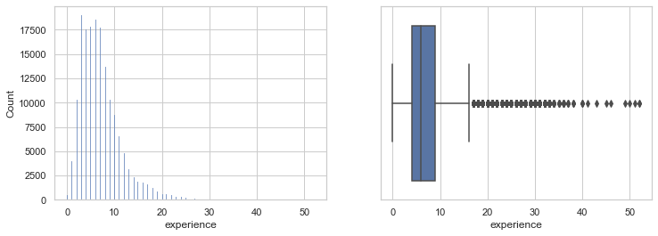

```python
fig, ax = plt.subplots(1,2, figsize=(12,4))
sns.histplot(df['experience'], ax=ax[0])
sns.boxplot(x=df['experience'], ax=ax[1])
plt.show()
```

```python
#defect outliers using simple IQR
def findoutliers(arr):
    q3 = np.percentile(arr, 75)
    q1 = np.percentile(arr, 25)
    iqr = q3-q1
    ulim = q3 + 1.5*iqr
    llim = q1 - 1.5*iqr
    return pd.Series([True if((ele > ulim) or (ele < llim)) else False for ele in arr])

#outliers_mask = findoutliers(df['experience'])
#df[outliers_mask].shape[0]
df[df['experience'] > 25].shape
```

```
(535, 7)
```

**Observation:** The distribution of 'experience' is somewhat right skewed with several outliers on the right tail. From the histpgram, experience value 25 looks like a good cut off point for cluster analysis.

```python
#delete outlier rows
df.drop(df[df['experience'] > 25].index, inplace=True)
df = df.reset_index(drop=True)
```

### create 'experience_level' categorical feature

For more meaningful analysis, we can create 'experience_level' categorical feature from 'experience'.

```python
df['experience_level'] = pd.cut(df['experience'], bins=[-1, 0, 2, 5, 9, 12, 15, 20, 30, 55], labels=['0', '1-2', '3-5', '6-9', '10-12','12-15', '16-20', '21-30', '30+'])
df['experience_level'] = df['experience_level'].astype('category')
```

```python
df['experience_level'].value_counts()
```

```
6-9      60298
3-5      54299
10-12    20173
1-2      14258
12-15     7363
16-20     6059
21-30     1845
0          483
30+          0
Name: experience_level, dtype: int64
```

```python
df.info()
```

```
<class 'pandas.core.frame.DataFrame'>
RangeIndex: 164778 entries, 0 to 164777
Data columns (total 8 columns):
 #   Column            Non-Null Count   Dtype
---  ------            --------------   -----
 0   company_hash      164778 non-null  object
 1   email_hash        164778 non-null  object
 2   orgyear           164778 non-null  float64
 3   ctc               164778 non-null  float64
 4   job_position      164778 non-null  object
 5   ctc_updated_year  164778 non-null  float64
 6   experience        164778 non-null  float64
 7   experience_level  164778 non-null  category
dtypes: category(1), float64(4), object(3)
memory usage: 9.0+ MB
```

### Analyzing 'ctc'

```python
df['ctc'].describe()
```

```
count    1.647780e+05
mean     2.442119e+06
std      1.273094e+07
min      2.000000e+00
25%      5.500000e+05
50%      9.600000e+05
75%      1.700000e+06
max      1.000150e+09
Name: ctc, dtype: float64
```

```python
np.percentile(df['ctc'], range(5,100,5))
```

```
array([ 200000.,  340000.,  400000.,  480000.,  550000.,  600000.,
        700000.,  780000.,  850000.,  960000., 1050000., 1200000.,
       1340000., 1500000., 1700000., 2000000., 2300000., 2850000.,
       3900000.])
```

```python
#check range for [3,97] percentile
np.percentile(df['ctc'], [3,97])
```

```
array([ 100000., 5000000.])
```

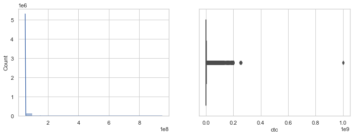

```python
ctc_vals = np.array(list(map(lambda x:np.round((x.left + x.right)/2), list(pd.cut(df['ctc'], 10)))))
fig, ax = plt.subplots(1,2, figsize=(12,4))
sns.histplot(ctc_vals, kde=True, ax=ax[0])
sns.boxplot(x=df['ctc'], ax=ax[1])
plt.show()
```

**Observation:** As we can see, 'ctc' has a highly positively skewed distribution with a lot of outliers. 'ctc' values range from 2 to 1000150000 (1 billion), with mean at 2448667 (24.5 lacs), and median at 960000 (9.6 lacs). Since distance-based clustering algorithms are sensitive to outliers and are generally adversely impacted by highly skewed data, we will first log transform CTC and then remove outliers.

### create 'ctc_log' feature

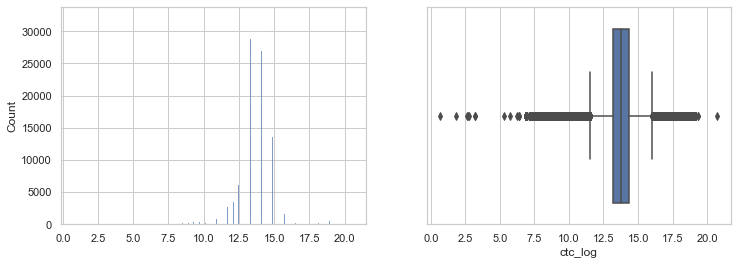

```python
df['ctc_log'] = np.log(df['ctc'])
ctc_vals = np.array(list(map(lambda x:np.round((x.left + x.right)/2, 2), list(pd.cut(df['ctc_log'], 50)))))
fig, ax = plt.subplots(1,2, figsize=(12,4))
sns.histplot(ctc_vals, ax=ax[0])
sns.boxplot(x=df['ctc_log'], ax=ax[1])
plt.show()
```

```python
q3 = np.percentile(df['ctc_log'], 75)
q1 = np.percentile(df['ctc_log'], 25)
iqr = q3-q1
ulim = q3 + 1.5*iqr
llim = q1 - 1.5*iqr

print(f'Inliers ctc range: ctc_log ({llim}, {ulim}) or ctc ({np.exp(llim)}, {np.exp(ulim)})')
```

```
Inliers ctc range: ctc_log (11.524975679481969, 16.03883668675313) or ctc (101212.31108578993, 9238006.621620089)
```

```python
outlier_mask = ((df['ctc_log'] < llim) | (df['ctc_log'] > ulim))
df[outlier_mask].shape
```

```
(7451, 9)
```

```python
#remove outliers
df.drop(df[outlier_mask].index, inplace=True)
df = df.reset_index(drop=True)
```

```python
# bottom_3_ctc = np.percentile(df['ctc'], 3)
# top_3_ctc = np.percentile(df['ctc'], 97)

# inlier_mask = ((df['ctc'] >= bottom_3_ctc) & (df['ctc'] <= top_3_ctc))

# #remove outliers
# df.drop(df[~inlier_mask].index, inplace=True)
# df = df.reset_index(drop=True)
```

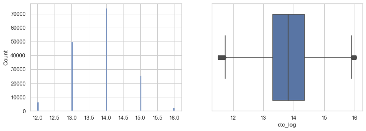

```python
ctc_vals = np.array(list(map(lambda x:np.round((x.left + x.right)/2), list(pd.cut(df['ctc_log'], 30)))))
fig, ax = plt.subplots(1,2, figsize=(12,4))
sns.histplot(ctc_vals, ax=ax[0])
sns.boxplot(x=df['ctc_log'], ax=ax[1])
plt.show()
```

**observation:** : The distribution looks better after log transforming ctc and removing outliers.

### Calculate CTC stats by company, job position, and experience

To make comparisons more meaningful, we will use 'experience_level' rather than 'experience'

```python
def perc_factory(n):
    def percentile_(x):
        return np.percentile(x, n)
    return percentile_

perc33 = perc_factory(33)
perc66 = perc_factory(66)

ctc_by_c_jp_exp = df.groupby(['company_hash', 'job_position', 'experience_level']).agg({'ctc': ['count', 'min', 'max', 'mean', 'median', perc33, perc66]})
ctc_by_c_jp_exp.columns = ['ctc_count', 'ctc_min', 'ctc_max', 'ctc_mean', 'ctc_median', 'perc33', 'perc66']
ctc_by_c_jp_exp = ctc_by_c_jp_exp.reset_index()
ctc_by_c_jp_exp.sort_values(by='ctc_count', ascending=False).head()
```

|  | company_hash | job_position | experience_level | ctc_count | ctc_min | ctc_max | ctc_mean | ctc_median | perc33 | perc66 |
| --- | --- | --- | --- | --- | --- | --- | --- | --- | --- | --- |
| 2769545 | nvnvwgzohrnvzwjotqcxwto | backendengineer | 3-5 | 777 | 300000.0 | 8000000.0 | 5.294182e+05 | 409999.0 | 400000.0 | 500000.0 |
| 5402046 | vbvkgz | backendengineer | 6-9 | 610 | 120000.0 | 9000000.0 | 2.675001e+06 | 2500000.0 | 1900000.0 | 3200000.0 |
| 1175303 | eqtoytq | other | 3-5 | 576 | 180000.0 | 8000000.0 | 9.815694e+05 | 700000.0 | 500000.0 | 1000000.0 |
| 2769653 | nvnvwgzohrnvzwjotqcxwto | other | 3-5 | 505 | 190000.0 | 2930000.0 | 4.923890e+05 | 400000.0 | 360000.0 | 459999.0 |
| 6900851 | xzegojo | fullstackengineer | 3-5 | 496 | 200000.0 | 3960000.0 | 6.012863e+05 | 500000.0 | 450000.0 | 650000.0 |

### Calculate CTC stats by company and job position

```python
ctc_by_c_jp = df.groupby(['company_hash', 'job_position']).agg({'ctc': ['count', 'min', 'max', 'mean', 'median', perc33, perc66]})
ctc_by_c_jp.columns = ['ctc_count', 'ctc_min', 'ctc_max', 'ctc_mean', 'ctc_median', 'perc33', 'perc66']
ctc_by_c_jp = ctc_by_c_jp.reset_index()
ctc_by_c_jp.sort_values(by='ctc_count', ascending=False).head()
```

|  | company_hash | job_position | ctc_count | ctc_min | ctc_max | ctc_mean | ctc_median | perc33 | perc66 |
| --- | --- | --- | --- | --- | --- | --- | --- | --- | --- |
| 19967 | nvnvwgzohrnvzwjotqcxwto | backendengineer | 1380 | 150000.0 | 8500000.0 | 6.175984e+05 | 460000.0 | 400000.0 | 633420.0 |
| 38769 | vbvkgz | backendengineer | 1271 | 110000.0 | 9000000.0 | 2.565029e+06 | 2400000.0 | 1800000.0 | 3000000.0 |
| 19979 | nvnvwgzohrnvzwjotqcxwto | other | 1063 | 110000.0 | 3000000.0 | 5.099073e+05 | 400000.0 | 350000.0 | 500000.0 |
| 19976 | nvnvwgzohrnvzwjotqcxwto | fullstackengineer | 964 | 160000.0 | 7150000.0 | 6.493454e+05 | 550000.0 | 420000.0 | 700000.0 |
| 49583 | xzegojo | other | 921 | 140000.0 | 6800000.0 | 5.510716e+05 | 420000.0 | 390000.0 | 500000.0 |

### Calculate CTC stats by company

```python
ctc_by_c = df.groupby(['company_hash']).agg({'ctc': ['count', 'min', 'max', 'mean', 'median', perc33, perc66]})
ctc_by_c.columns = ['ctc_count', 'ctc_min', 'ctc_max', 'ctc_mean', 'ctc_median', 'perc33', 'perc66']
ctc_by_c = ctc_by_c.reset_index()
ctc_by_c['company_tier_perc'] = ctc_by_c['ctc_median'].transform(lambda c: np.round((percentileofscore(ctc_by_c['ctc_median'], c) / 100), 2))
ctc_by_c.sort_values(by='ctc_count', ascending=False).head()
```

|  | company_hash | ctc_count | ctc_min | ctc_max | ctc_mean | ctc_median | perc33 | perc66 | company_tier_perc |
| --- | --- | --- | --- | --- | --- | --- | --- | --- | --- |
| 12309 | nvnvwgzohrnvzwjotqcxwto | 5664 | 103000.0 | 9000000.0 | 6.108456e+05 | 459999.0 | 400000.0 | 630000.0 | 0.21 |
| 30670 | xzegojo | 3748 | 105000.0 | 9000000.0 | 6.482141e+05 | 500000.0 | 405000.0 | 600000.0 | 0.24 |
| 24009 | vbvkgz | 2608 | 105000.0 | 9200000.0 | 2.220623e+06 | 2000000.0 | 1370000.0 | 2688600.0 | 0.88 |
| 27354 | wgszxkvzn | 2266 | 102000.0 | 8900000.0 | 7.386892e+05 | 580000.0 | 450000.0 | 730000.0 | 0.29 |
| 32674 | zgnvuurxwvmrtvwwghzn | 2157 | 105000.0 | 9000000.0 | 8.639282e+05 | 600000.0 | 400000.0 | 800000.0 | 0.32 |

```python
df_feat_engg1 = df.copy()
```

```python
df_feat_engg1.to_csv('feat_engg_1.csv',index_label='index')
```

```python
#df = pd.read_csv('feat_engg_1.csv', index_col = 'index')
```

#### Add ctc(lacs) for display purpose

```python
df['ctc(lacs)'] = df['ctc'] / 100000
```

### create 'job_position_tier'

We can assign each job_position tier value of {1,2,3} based on their median CTC value. Companies with top 33% CTC values are considered tier1 job_positions, bottom 33% are considered tier 3 job_positions, and the remaining ones are tier2 job_positions. We will also create 'job_position_tier_perc' to denote the actual percentile rank of that job_position with regards to CTC.

```python
def get_quantile_fn(col_name, perc33_val, perc66_val):

    def compute_quantile(r):

        if r[col_name] >= perc33_val and r[col_name] <= perc66_val:
            return 2
        elif r[col_name] > perc66_val:
            return 1
        else:
            return 3

    return compute_quantile

ctc_by_jp = df.groupby('job_position')['ctc'].median().reset_index()

ctc_median_perc33 = np.percentile(ctc_by_jp['ctc'], 33)
ctc_median_perc66 = np.percentile(ctc_by_jp['ctc'], 66)

compute_jp_tier = get_quantile_fn('ctc', ctc_median_perc33, ctc_median_perc66)

ctc_by_jp['job_position_tier'] = ctc_by_jp.apply(compute_jp_tier, axis=1)
ctc_by_jp['job_position_tier_perc'] = ctc_by_jp['ctc'].transform(lambda c: np.round((percentileofscore(ctc_by_jp['ctc'], c) / 100), 2))

df2 = df.copy()
df2 = df2.reset_index().merge(ctc_by_jp, on=['job_position'], how="left").set_index('index')
df['job_position_tier'] = df2['job_position_tier']
df['job_position_tier_perc'] = df2['job_position_tier_perc']
```

```python
df[['job_position', 'job_position_tier',  'job_position_tier_perc']].drop_duplicates().sort_values(by='job_position_tier_perc', ascending=False).reset_index(drop=True)
```

|  | job_position | job_position_tier | job_position_tier_perc |
| --- | --- | --- | --- |
| 0 | backendarchitect | 1 | 1.00 |
| 1 | engineeringleadership | 1 | 0.96 |
| 2 | programmanager | 1 | 0.92 |
| 3 | productmanager | 1 | 0.88 |
| 4 | seniorsoftwareengineer | 1 | 0.84 |
| 5 | securityleadership | 2 | 0.72 |
| 6 | researchengineers | 2 | 0.72 |
| 7 | cofounder | 2 | 0.72 |
| 8 | datascientist | 2 | 0.72 |
| 9 | backendengineer | 2 | 0.72 |
| 10 | productdesigner | 2 | 0.60 |
| 11 | devopsengineer | 2 | 0.56 |
| 12 | fullstackengineer | 2 | 0.52 |
| 13 | androidengineer | 2 | 0.44 |
| 14 | frontendengineer | 2 | 0.44 |
| 15 | iosengineer | 2 | 0.44 |
| 16 | releaseengineer | 2 | 0.36 |
| 17 | engineeringintern | 3 | 0.32 |
| 18 | sdet | 3 | 0.28 |
| 19 | databaseadministrator | 3 | 0.24 |
| 20 | qaengineer | 3 | 0.18 |
| 21 | dataanalyst | 3 | 0.18 |
| 22 | other | 3 | 0.12 |
| 23 | supportengineer | 3 | 0.08 |
| 24 | noncoder | 3 | 0.04 |

### Create 'company_tier' and 'company_scale' features

1. **company_tier** - We can divide all companies based on their meadian CTC value into 3 tiers. Top 33% highest paying companies are given tier1 value, Bottom 33% are given tier 3, and remaining are tier2.
2. **company_scale** - based on the number of employed learners, we can divide the companies into three scales. Companies employing 1-5 learners are scale 3, 6-100 learners having scale 2, and having >100 learners as scale 1.

```python
ctc_median_perc33 = np.percentile(ctc_by_c['ctc_median'], 33)
ctc_median_perc66 = np.percentile(ctc_by_c['ctc_median'], 66)

company_scale_lim1 = 5
company_scale_lim2 = 100

compute_company_tier = get_quantile_fn('ctc_median', ctc_median_perc33, ctc_median_perc66)
compute_company_scale = get_quantile_fn('ctc_count', company_scale_lim1, company_scale_lim2)

ctc_by_c['company_tier'] = ctc_by_c.apply(compute_company_tier, axis=1)
ctc_by_c['company_scale'] = ctc_by_c.apply(compute_company_scale, axis=1)

df2 = df.copy()
df2 = df2.reset_index().merge(ctc_by_c, on=['company_hash'], how="left").set_index('index')
df['company_tier'] = df2['company_tier']
df['company_scale'] = df2['company_scale']
df['company_tier_perc'] = df2['company_tier_perc']
```

```python
np.round(df.groupby(['company_tier']).agg({'company_hash':'nunique', 'ctc(lacs)': ['mean', 'median'], 'experience': 'mean'}),2)
```

| company_tier | company_hash nunique | ctc(lacs) mean | ctc(lacs) median | experience mean |
| --- | --- | --- | --- | --- |
| 1 | 11447 | 19.88 | 16.8 | 8.00 |
| 2 | 12385 | 9.81 | 8.0 | 6.49 |
| 3 | 9984 | 5.48 | 4.3 | 5.47 |

### Create features for learner's relative performance.

We will create the following categories of features to denote a learner's performance/standing among his/her peers using ctc as the evaluation metric.

1. **'designation'** - Possible values are {1,2,3}. To calculate a learner's designation, we first find all peers of the learners **who are working at the same company, job position, and fall in the same experience level bucket**. Divide these peers into 3 groups (or designations) - 1,2, and 3. Top 33% are assigned designation 1, bottom 33% are assigned designation 3, and remaining learners are assigned designation 2.
2. **'class'** - Possible values are {1,2,3}. To calculate a learner's class, we first find all peers of the learners **who are working at the same company and in the same job position (regardless of their experience level)**. Divide these peers into 3 groups (or classes) - 1,2, and 3. Top 33% are assigned class 1, bottom 33% are assigned class 3, and remaining learners are assigned class 2.
3. **'tier'** - Possible values are {1,2,3}. To calculate a learner's tier, we first find all peers of the learners **who are working at the same company (regardless of their job designation or experience level)**. Divide these peers into 3 groups (or tiers) - 1,2, and 3. Top 33% are assigned tier 1, bottom 33% are assigned tier 3, and remaining learners are assigned tier 2.

**Imp Note**

1. We will also compute 'desination_perc', 'class_perc', and 'tier_perc' features denoting the actual percentile rank for that learner among his/her peer group.
2. When the peer group size is one (either because of lack of data or we only have one learner from that company/job_position), we try to estimate 'XXXX_perc' value by taking average of 'job_position_tier_perc' and 'company_tier_perc' values.

```python
df.info()
```

```
<class 'pandas.core.frame.DataFrame'>
RangeIndex: 157327 entries, 0 to 157326
Data columns (total 15 columns):
 #   Column                  Non-Null Count   Dtype
---  ------                  --------------   -----
 0   company_hash            157327 non-null  object
 1   email_hash              157327 non-null  object
 2   orgyear                 157327 non-null  float64
 3   ctc                     157327 non-null  float64
 4   job_position            157327 non-null  object
 5   ctc_updated_year        157327 non-null  float64
 6   experience              157327 non-null  float64
 7   experience_level        157327 non-null  category
 8   ctc_log                 157327 non-null  float64
 9   ctc(lacs)               157327 non-null  float64
 10  job_position_tier       157327 non-null  int64
 11  job_position_tier_perc  157327 non-null  float64
 12  company_tier            157327 non-null  int64
 13  company_scale           157327 non-null  int64
 14  company_tier_perc       157327 non-null  float64
dtypes: category(1), float64(8), int64(3), object(3)
memory usage: 17.0+ MB
```

```python
def compute_quantiles(r):

    if r['ctc'] >= r['perc33'] and r['ctc'] <= r['perc66']:
        return 2
    elif r['ctc'] > r['perc66']:
        return 1
    else:
        return 3

#merge df2 with right dataframe and retain df2's index. This will allow us to assign new columns directly to df
df2 = df_feat_engg1.copy()
df2 = df2.reset_index().merge(ctc_by_c_jp_exp, on=['company_hash', 'job_position', 'experience_level'], how="left").set_index('index')
df['designation'] = df2.apply(compute_quantiles, axis=1)

df2 = df_feat_engg1.copy()
df2 = df2.reset_index().merge(ctc_by_c_jp, on=['company_hash', 'job_position'], how="left").set_index('index')
df['class'] = df2.apply(compute_quantiles, axis=1)

df2 = df_feat_engg1.copy()
df2 = df2.reset_index().merge(ctc_by_c, on=['company_hash'], how="left").set_index('index')
df['tier'] = df2.apply(compute_quantiles, axis=1)
```

```python
def get_compute_percentile_fn(col_name, col_to_compare='ctc'):
    def compute_percentile(df):
        peer_ctc = df[col_to_compare].values.copy()
        if len(peer_ctc) == 1:
            df[col_name] = -1 #impute later
        else:
            df[col_name] = np.round(df[col_to_compare].transform(lambda c: percentileofscore(peer_ctc, c) / 100), 2)

        return df

    return compute_percentile

df = df.groupby(['company_hash', 'job_position', 'experience_level']).apply(get_compute_percentile_fn('designation_perc'))
df = df.groupby(['company_hash', 'job_position']).apply(get_compute_percentile_fn('class_perc'))
df = df.groupby(['company_hash']).apply(get_compute_percentile_fn('tier_perc'))
```

```python
#impute values
def impute_values_from_hierarchy(ser):
    if(ser['tier_perc'] == -1):
        ser['tier_perc'] = np.mean([ser['job_position_tier_perc'], ser['company_tier_perc']])
    if(ser['class_perc'] == -1):
        ser['class_perc'] = ser['tier_perc']
    if(ser['designation_perc'] == -1):
        ser['designation_perc'] = ser['tier_perc']

    return ser

df = df.apply(impute_values_from_hierarchy, axis=1)
```

```python
np.round(df.groupby(['designation']).agg({'ctc(lacs)': ['mean', 'median'], 'experience': 'mean'}),2)
```

| designation | ctc(lacs) mean | ctc(lacs) median | experience mean |
| --- | --- | --- | --- |
| 1 | 19.52 | 15.4 | 6.63 |
| 2 | 12.35 | 9.0 | 7.22 |
| 3 | 8.54 | 6.6 | 6.49 |

```python
np.round(df.groupby(['class']).agg({'ctc(lacs)': ['mean', 'median'], 'experience': 'mean'}),2)
```

| class | ctc(lacs) mean | ctc(lacs) median | experience mean |
| --- | --- | --- | --- |
| 1 | 20.80 | 17.0 | 7.93 |
| 2 | 11.85 | 9.0 | 6.98 |
| 3 | 7.79 | 6.0 | 5.75 |

```python
np.round(df.groupby(['tier']).agg({'ctc(lacs)': ['mean', 'median'], 'experience': 'mean'}),2)
```

| tier | ctc(lacs) mean | ctc(lacs) median | experience mean |
| --- | --- | --- | --- |
| 1 | 22.00 | 18.3 | 8.51 |
| 2 | 11.34 | 9.0 | 6.76 |
| 3 | 6.76 | 5.6 | 5.50 |

```python
df_feat_engg2 = df.copy()
```

```python
df_feat_engg2.to_csv('feat_engg2.csv', index_label='index')
```

```python
#df = pd.read_csv('feat_engg2.csv', index_col = 'index')
```

```python
df.info()
```

```
<class 'pandas.core.frame.DataFrame'>
Int64Index: 157327 entries, 0 to 157326
Data columns (total 21 columns):
 #   Column                  Non-Null Count   Dtype
---  ------                  --------------   -----
 0   company_hash            157327 non-null  object
 1   email_hash              157327 non-null  object
 2   orgyear                 157327 non-null  float64
 3   ctc                     157327 non-null  float64
 4   job_position            157327 non-null  object
 5   ctc_updated_year        157327 non-null  float64
 6   experience              157327 non-null  float64
 7   experience_level        157327 non-null  object
 8   ctc_log                 157327 non-null  float64
 9   ctc(lacs)               157327 non-null  float64
 10  job_position_tier       157327 non-null  int64
 11  job_position_tier_perc  157327 non-null  float64
 12  company_tier            157327 non-null  int64
 13  company_scale           157327 non-null  int64
 14  company_tier_perc       157327 non-null  float64
 15  designation             157327 non-null  int64
 16  class                   157327 non-null  int64
 17  tier                    157327 non-null  int64
 18  designation_perc        157327 non-null  float64
 19  class_perc              157327 non-null  float64
 20  tier_perc               157327 non-null  float64
dtypes: float64(11), int64(6), object(4)
memory usage: 30.4+ MB
```

### aggregate data at learner level

Now that we have created features from the all available data, before we cluster learners, we will aggregate data at learner level. For each learner, we now pick his current (last job with highest ctc_updated_year/orgyear) job details including 'ctc', 'company_hash', experience details, designation, class, and tier. We can discard orgyear/crtc_updated_year details as the absolute year details will not be meaningful.

```python
#sort dataframe by newest jobs to oldest jobs, and group by email_hash
df = df.sort_values(by=['ctc_updated_year', 'orgyear'], ascending=[False, False]).groupby('email_hash').agg({
    'ctc': 'first',
    'ctc_log': 'first',

    'experience': 'first',
    'experience_level': 'first',

    'designation': 'first',
    'class': 'first',
    'tier': 'first',
    'job_position_tier': 'first',
    'company_tier': 'first',
    #'company_scale': 'first',

    'designation_perc': 'first',
    'class_perc': 'first',
    'tier_perc': 'first',
    'job_position_tier_perc': 'first',
    'company_tier_perc': 'first',

    'company_hash': 'first',
    'job_position': 'first'
}).reset_index()
```

```python
df_agg = df.copy()
```

```python
df_agg.to_csv('learners_agg.csv', index_label='index')
```

```python
#df = pd.read_csv('learners_agg.csv' ,index_col='index')
```

```python
#Add ctc(lacs) column for better display
df['ctc(lacs)'] = np.round(df['ctc'] / 100000, 2)
```

```python
df.head()
```

| index | email_hash | ctc | ctc_log | experience | experience_level | designation | class | tier | job_position_tier | company_tier | designation_perc | class_perc | tier_perc | job_position_tier_perc | company_tier_perc | company_hash | job_position | ctc(lacs) |
| --- | --- | --- | --- | --- | --- | --- | --- | --- | --- | --- | --- | --- | --- | --- | --- | --- | --- | --- |
| 0 | 00003288036a44374976948c327f246fdbdf0778546904... | 3500000.0 | 15.068274 | 10.0 | 10-12 | 2 | 1 | 1 | 2 | 1 | 0.650 | 0.730 | 0.750 | 0.72 | 0.92 | bxwqgogen | backendengineer | 35.0 |
| 1 | 0000aaa0e6b61f7636af1954b43d294484cd151c9b3cf6... | 250000.0 | 12.429216 | 9.0 | 6-9 | 2 | 2 | 2 | 2 | 3 | 0.395 | 0.395 | 0.395 | 0.72 | 0.07 | nqsnaxsxnvr | backendengineer | 2.5 |
| 2 | 0000d58fbc18012bf6fa2605a7b0357d126ee69bc41032... | 1300000.0 | 14.077875 | 3.0 | 3-5 | 1 | 2 | 2 | 2 | 1 | 0.770 | 0.670 | 0.580 | 0.72 | 0.69 | gunhb | backendengineer | 13.0 |
| 3 | 000120d0c8aa304fcf12ab4b85e21feb80a342cfea03d4... | 2000000.0 | 14.508658 | 18.0 | 16-20 | 2 | 1 | 2 | 2 | 1 | 0.680 | 1.000 | 0.680 | 0.52 | 0.71 | bxwqgotbxwgqugqvnxgz | fullstackengineer | 20.0 |
| 4 | 00014d71a389170e668ba96ae8e1f9d991591acc899025... | 3400000.0 | 15.039286 | 13.0 | 12-15 | 2 | 1 | 1 | 3 | 1 | 0.500 | 0.870 | 0.770 | 0.12 | 0.92 | fvrbvqnrvmo | other | 34.0 |

## Univariate and Bivariate analysis

```python
#Common utility functions
def showpercent(ax, total):
    for p in ax.patches:
            percent = '{:.1f}%'.format(100 * p.get_height()/total)
            xpos = p.get_x() + p.get_width()/2
            ypos = p.get_height()
            ax.annotate(percent, (xpos, ypos),ha='center', va='bottom')

def showpercent_with_hue(ax, hue_levels, x_levels):

    heights_arr = np.array([p.get_height() for p in ax.patches])
    heights = pd.Series([p.get_height() for p in ax.patches]).fillna(0).values.reshape((hue_levels, int(len(heights_arr)/hue_levels)))
    percents = np.round((heights * 100) / np.sum(heights, axis=0)+0.001,1)
    perclist = percents.flatten(order='C') #flatten in column-major (F-style) order

    for i in range(len(ax.patches)):
        p = ax.patches[i]
        percent = f'{perclist[i]}%'
        xpos = p.get_x() + p.get_width()/2
        ypos = p.get_height()

        ax.annotate(percent, (xpos, ypos),ha='center', va='bottom')
```

### 'ctc' and 'ctc_log'

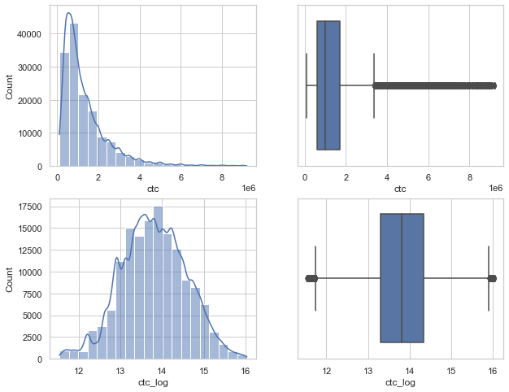

```python
fig, ax = plt.subplots(2,2, figsize=(10,8))

sns.histplot(x=df['ctc'], bins=20, kde=True, ax=ax[0][0])
sns.boxplot(x=df['ctc'], ax=ax[0][1])

sns.histplot(x=df['ctc_log'], bins=20, kde=True, ax=ax[1][0])
sns.boxplot(x=df['ctc_log'], ax=ax[1][1])

plt.show()
```

### experience and experience_level

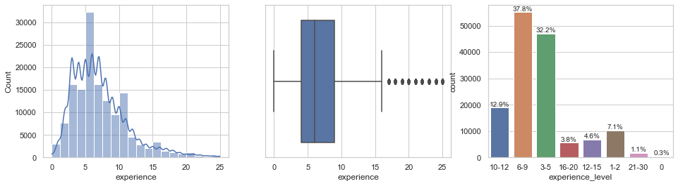

```python
fig, ax = plt.subplots(1,3, figsize=(16,4))

sns.histplot(x=df['experience'], bins=20, kde=True, ax=ax[0])
sns.boxplot(x=df['experience'], ax=ax[1])
sns.countplot(x=df['experience_level'], ax=ax[2])
showpercent(ax[2], df.shape[0])

plt.show()
```

### experience_level and average CTC

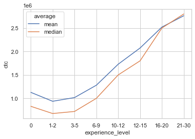

```python
data = df.groupby('experience_level')['ctc'].agg(['mean', 'median']).reset_index()
data['exp_left_edge'] = data['experience_level'].transform(lambda x: int(x[:x.index('-')]) if('-' in x) else int(x))
data = data.sort_values(by='exp_left_edge')
data = data.set_index('experience_level')[['mean', 'median']].stack().reset_index().rename(columns={'level_1': 'average', 0:'ctc'})

sns.lineplot(x='experience_level', y='ctc', hue='average', data=data)
```

### designation and designation_perc

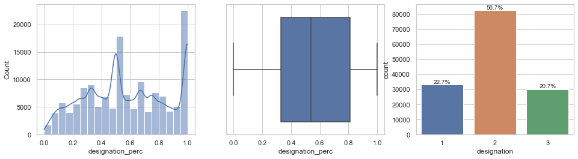

```python
fig, ax = plt.subplots(1,3, figsize=(16,4))

sns.histplot(x=df['designation_perc'], bins=20, kde=True, ax=ax[0])
sns.boxplot(x=df['designation_perc'], ax=ax[1])
sns.countplot(x=df['designation'], ax=ax[2])
showpercent(ax[2], df.shape[0])

plt.show()
```

### class_perc and class

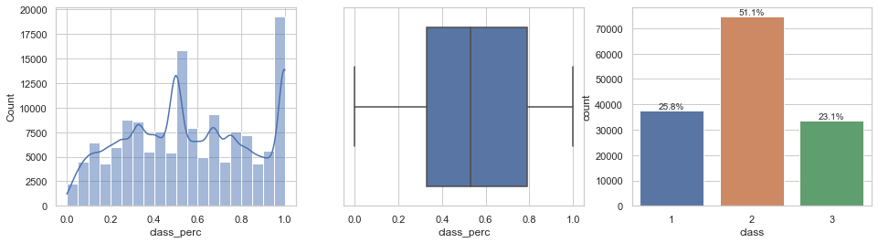

```python
fig, ax = plt.subplots(1,3, figsize=(16,4))

sns.histplot(x=df['class_perc'], bins=20, kde=True, ax=ax[0])
sns.boxplot(x=df['class_perc'], ax=ax[1])
sns.countplot(x=df['class'], ax=ax[2])
showpercent(ax[2], df.shape[0])

plt.show()
```

### tier_perc and tier

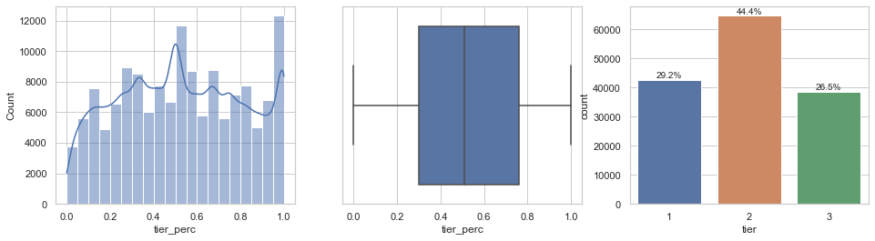

```python
fig, ax = plt.subplots(1,3, figsize=(16,4))

sns.histplot(x=df['tier_perc'], bins=20, kde=True, ax=ax[0])
sns.boxplot(x=df['tier_perc'], ax=ax[1])
sns.countplot(x=df['tier'], ax=ax[2])
showpercent(ax[2], df.shape[0])

plt.show()
```

### designation, class, and tier and their average CTC

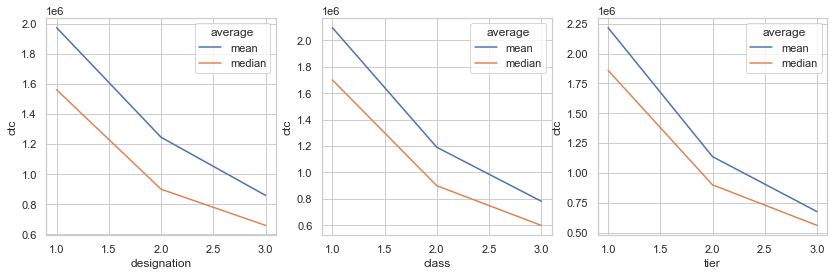

```python
cols = ['designation', 'class', 'tier']
fig, ax = plt.subplots(1, 3, figsize=(14, 4))

for i, col in enumerate(cols):
    data = df.groupby(col)['ctc'].agg(['mean', 'median']).reset_index()
    data = data.sort_values(by=col)
    data = data.set_index(col)[['mean', 'median']].stack().reset_index().rename(columns={'level_1': 'average', 0:'ctc'})

    sns.lineplot(x=col, y='ctc', hue='average', data=data, ax=ax[i])
```

### company_tier_perc and company_tier

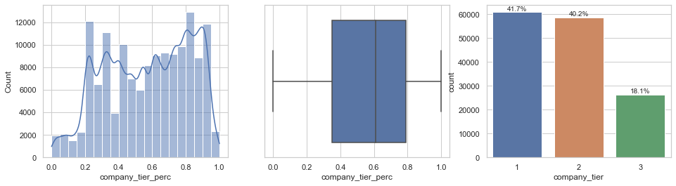

```python
fig, ax = plt.subplots(1,3, figsize=(16,4))

sns.histplot(x=df['company_tier_perc'], bins=20, kde=True, ax=ax[0])
sns.boxplot(x=df['company_tier_perc'], ax=ax[1])
sns.countplot(x=df['company_tier'], ax=ax[2])
showpercent(ax[2], df.shape[0])

plt.show()
```

### job_position_tier

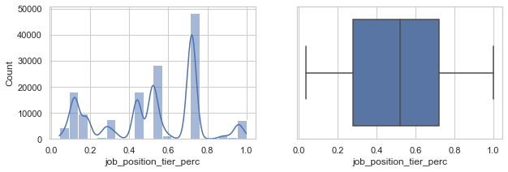

```python
fig, ax = plt.subplots(1,2, figsize=(10,3))
sns.histplot(x=df['job_position_tier_perc'], bins=20, kde=True, ax=ax[0])
sns.boxplot(x=df['job_position_tier_perc'], ax=ax[1])
plt.show()
```

### job_position

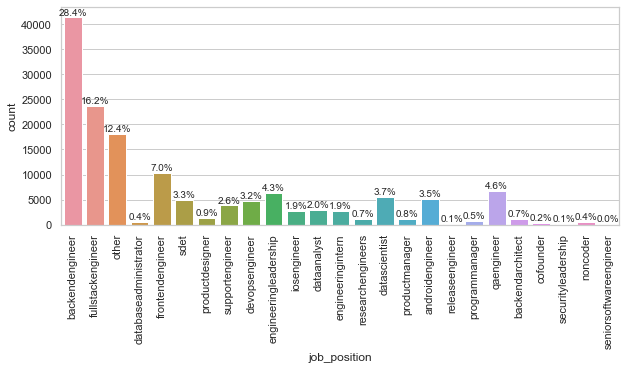

```python
fig, ax = plt.subplots(1,1, figsize=(10,4))
sns.countplot(x=df['job_position'], ax=ax)
showpercent(ax, df.shape[0])
plt.xticks(rotation = 90)
plt.show()
```

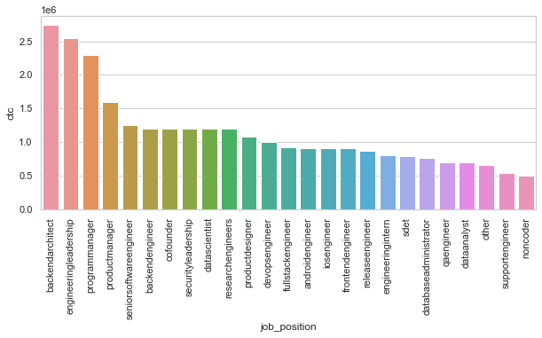

```python
data = ctc_by_jp.sort_values(by='ctc', ascending=False)
x = data['job_position']
y = data['ctc']

fig, ax = plt.subplots(1,1, figsize=(10,4))
sns.barplot(x=x, y=y, ax=ax)
plt.xticks(rotation = 90)
plt.show()
```

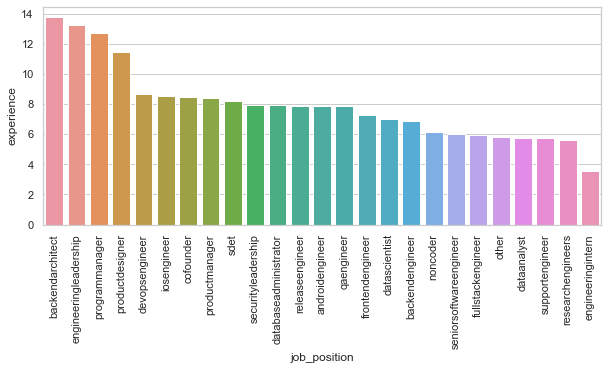

```python
data = df.groupby('job_position')['experience'].mean().sort_values(ascending=False).reset_index()

x = data['job_position']
y = data['experience']

fig, ax = plt.subplots(1,1, figsize=(10,4))
sns.barplot(x=x, y=y, ax=ax)
plt.xticks(rotation = 90)
plt.show()
```

### company_tier, job_position_tier and average ctc

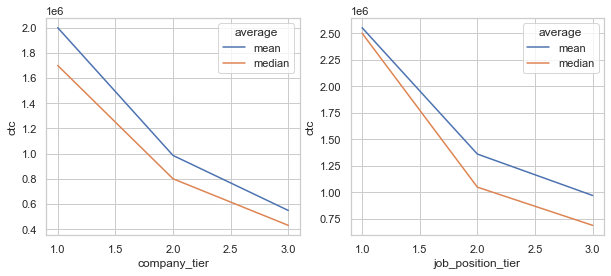

```python
cols = ['company_tier', 'job_position_tier']
fig, ax = plt.subplots(1, 2, figsize=(10, 4))

for i, col in enumerate(cols):
    data = df.groupby(col)['ctc'].agg(['mean', 'median']).reset_index()
    data = data.sort_values(by=col)
    data = data.set_index(col)[['mean', 'median']].stack().reset_index().rename(columns={'level_1': 'average', 0:'ctc'})

    sns.lineplot(x=col, y='ctc', hue='average', data=data, ax=ax[i])
```

### Correlation among continuous features

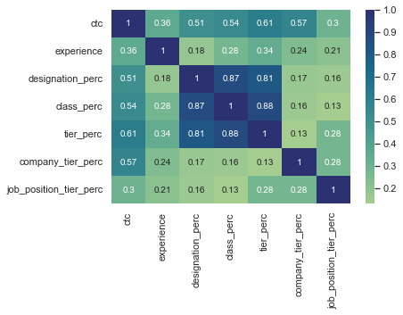

```python
data = np.round(df[['ctc', 'experience', 'designation_perc', 'class_perc', 'tier_perc', 'company_tier_perc', 'job_position_tier_perc']].corr(), 2)
sns.heatmap(data, cmap="crest", annot=True)
```

**Observations:**

1. Distribution of ctc is positively skewed, however, ctc_log distribution is symmetrical. For clustering, we will use ctc_log
2. In general, mean and median income for learners increase with experience, the exception being 1-2 years experience range where average income dips from 0-1 experience group. This is somewhat unexpected.
3. For designation, class, and tier features, as the level increase from 1 to 3, their mean/median CTC drops considerably. This is entirely expected because of the way we computed these features.
4. Similarly, for company_tier, and job_position_tier features, as the level increase from 1 to 3, their mean/median CTC drops considerably.
5. Top 5 lucative job_positions are 'backend architect', 'engineering leadership', 'program manager', 'product manager', and 'senior software enginner'. Least lucrative job_positions include 'non-coders', 'support engineers', 'data analyst', and 'qa engineers'. However, there is a catch. Most of the highest paying job_positions also have highest average experience, similary, most of the low paying job_positions are also associated with low experience.
6. There is a strong positive correlation among designation, class, and tier percentile features.
7. designation, class, tier, and company_tier are all moderately positivly correlated with CTC.
8. There is a weak positive correlation between experience and CTC.

## Manual clustering

Based on the features derived in the previous section, we can create manual clusters of learners as shown below.

#### Clusters based on 'designation'

```python
np.round(df.groupby(['designation']).agg({'email_hash':'nunique', 'ctc(lacs)': ['mean', 'median'], 'experience': 'mean'}),2)
```

| designation | email_hash nunique | ctc(lacs) mean | ctc(lacs) median | experience mean |
| --- | --- | --- | --- | --- |
| 1 | 33064 | 19.72 | 15.6 | 6.82 |
| 2 | 82669 | 12.45 | 9.0 | 7.42 |
| 3 | 30185 | 8.59 | 6.6 | 6.67 |

**Interpretation:**

Designation 1 are highest paid learners among their peers with their average CTC being significantly higher than the rest of their peers; Their average experience, on the other hand, is only marginally more than designation 3 employees and lower than that of designation 2 employees. Thus designation 1 learners are the brightest and highest performing learners. Designation 2 learners are relatively lesser paid learners with average experience relatively higher than the other groups. Thus they represent average learners with potential to grow. Designation 3 employees are paid the lowest among their peers, possibly an indication of weaker performance or lack of necessary skills.

#### Clusters based on 'class'

```python
np.round(df.groupby(['class']).agg({'email_hash': 'nunique','ctc(lacs)': ['mean', 'median'], 'experience': 'mean'}),2)
```

| class | email_hash nunique | ctc(lacs) mean | ctc(lacs) median | experience mean |
| --- | --- | --- | --- | --- |
| 1 | 37667 | 20.95 | 17.0 | 8.13 |
| 2 | 74543 | 11.91 | 9.0 | 7.16 |
| 3 | 33708 | 7.83 | 6.0 | 5.95 |

**Interpretation:**

Class1 learners consists of higher experience (average experience of 8.1 years) professional with significantly higher average pay than their peers working in the same company and job_position. Class2 learners have relatively lesser average experience (7.1 years) and lower average pay than their class1 peers. Class3 learners are lowest paid but also has relatively lowest experience.

#### Clusters based on 'tier'

```python
np.round(df.groupby(['tier']).agg({'email_hash': 'count', 'ctc(lacs)': ['mean', 'median'], 'experience': 'mean'}),2)
```

| tier | email_hash count | ctc(lacs) mean | ctc(lacs) median | experience mean |
| --- | --- | --- | --- | --- |
| 1 | 42571 | 22.18 | 18.6 | 8.74 |
| 2 | 64741 | 11.36 | 9.0 | 6.93 |
| 3 | 38606 | 6.76 | 5.6 | 5.69 |

**Interpretation:**

Tier1 learners are highest paid employees in their company and also happen to be most experienced employees. Tier2 employees are paid relatively lesser than tier1 peers but also have lower exprience. Tier3 group consists of learners who are paid the lowest in their company and have the lowest average experience.

#### Clusters based on 'company_tier'

```python
np.round(df.groupby(['company_tier']).agg({'email_hash': 'nunique', 'ctc(lacs)': ['mean', 'median'], 'experience': 'mean'}),2)
```

| company_tier | email_hash nunique | ctc(lacs) mean | ctc(lacs) median | experience mean |
| --- | --- | --- | --- | --- |
| 1 | 60878 | 20.00 | 17.0 | 8.20 |
| 2 | 58672 | 9.86 | 8.0 | 6.69 |
| 3 | 26368 | 5.48 | 4.3 | 5.64 |

**Interpretation:** Learners can be clustered into 3 groups based on the tier of their companywith Tier1 companies offering the highest mean pay and tier3 offering the lowest mean pay.

### Insights from Manual clustering

#### 1. Top 10 employees (earning more than most of the employees in the company) - Tier 1

```python
def compute_rank(d):
    d['rank'] = np.array(range(1, d.shape[0]+1))
    return d

tier1_learners = df[df['tier'] == 1].copy()
ranked_learners = tier1_learners.sort_values(by=['ctc'], ascending=[False]).groupby('company_hash').apply(compute_rank)
top_10 = ranked_learners[ranked_learners['rank'] <= 10]
top_10.sort_values(by=['company_hash', 'rank'], ascending=[False, False])[['company_hash', 'email_hash', 'rank', 'ctc', 'experience']]
```

|  | company_hash | email_hash | rank | ctc | experience |
| --- | --- | --- | --- | --- | --- |
| 71283 | zz | 7d4588453bc463b39db8c77ef0f856957fc42f5d54cae4... | 1 | 1370000.0 | 9.0 |
| 135071 | zycoxzaxv | ed0a1202c31bdee343662f5517fc467fb8b96ccaf8e3eb... | 1 | 600000.0 | 9.0 |
| 32299 | zxztrtvuo | 3879b9a1e356ed20363fffd6871207eb908b38c864a2db... | 10 | 1500000.0 | 5.0 |
| 13259 | zxztrtvuo | 16c227291d7c4f151b52599cc15e1ddd6f7e12a694753c... | 9 | 1780000.0 | 7.0 |
| 29442 | zxztrtvuo | 3385dc93ba44f4f1cc237ef4f8e057dab2f693d8961b64... | 8 | 1800000.0 | 9.0 |
| ... | ... | ... | ... | ... | ... |
| 28458 | 1bs | 31db7b806a82aac024462d4c97e70eed918bf8c3193b7c... | 1 | 3750000.0 | 6.0 |
| 28964 | 159ogrhnxgzo | 32b7af6a22321bae56df8b23ed279c1ec83098b2d42690... | 1 | 800000.0 | 4.0 |
| 12872 | 123ongqto | 160c93562f03a86198438f7b0ba964d1031e7b8c13c9d2... | 1 | 2560000.0 | 6.0 |
| 98035 | 10nxbto | abf1baa6163b89982e1a66ea5eca355109946e5030f342... | 1 | 500000.0 | 3.0 |
| 128693 | 01ojztqsj | e1e15fada844f35fcc33927343d0c80f55526b87c40eee... | 1 | 830000.0 | 11.0 |

20127 rows × 5 columns

#### 2. Top 10 employees of data science in Amazon / TCS etc earning more than their peers - Class 1

Note: we will take 'zvz' company_hash in our solution.

```python
learners = df[(df['class'] == 1) & (df['company_hash'] == 'zvz') & (df['job_position'] == 'datascientist')]
learners.sort_values(by='ctc', ascending=False)[['email_hash', 'ctc', 'experience', 'class', 'designation', 'tier']].head(10)
```

|  | email_hash | ctc | experience | class | designation | tier |
| --- | --- | --- | --- | --- | --- | --- |
| 24023 | 29d87536746f4ce38d9404695b4f0686c07fd9864d30b1... | 8360000.0 | 9.0 | 1 | 1 | 1 |
| 23342 | 28ab43a2ffc7954f01657b9a366a7eac703a4573388f73... | 4500000.0 | 4.0 | 1 | 1 | 1 |
| 54825 | 601750bf98bc9ecac24f0c1cf2f74f4cdd7e159666a778... | 4000000.0 | 4.0 | 1 | 1 | 1 |
| 70124 | 7b48a8e29d116bb1ed6c2728da80c20b426c5041570286... | 3200000.0 | 4.0 | 1 | 1 | 1 |
| 90766 | 9f46b2ea1ed7e21fbdc6c92207e9c71c59a3c9ca435b2f... | 3000000.0 | 1.0 | 1 | 1 | 1 |
| 118219 | cf83c09b40f463a93d7c66f6de83c84a3dbea0a7df0652... | 2800000.0 | 3.0 | 1 | 1 | 1 |
| 116684 | cccd80969d18917f68b1d38cdbd474e8111091e73b1fbf... | 2800000.0 | 2.0 | 1 | 1 | 1 |
| 101609 | b2356a9d3645fea65d5b8da3c7333dcdda01dac326618c... | 2800000.0 | 2.0 | 1 | 1 | 1 |
| 145630 | ff72ad9805c95aa037370c3a69b266fd99295a6ce005ec... | 2800000.0 | 2.0 | 1 | 1 | 1 |
| 32830 | 3962a72ca309a1c3cb70d31505aaa0a57ece5240dc25ba... | 2100000.0 | 1.0 | 1 | 1 | 1 |

#### 3. Bottom 10 employees of data science in Amazon / TCS etc earning less than their peers - Class 3

```python
learners = df[(df['class'] == 3) & (df['company_hash'] == 'zvz') & (df['job_position'] == 'datascientist')]
learners.sort_values(by='ctc', ascending=True)[['email_hash', 'ctc', 'experience', 'class', 'designation', 'tier']].head(10)
```

|  | email_hash | ctc | experience | class | designation | tier |
| --- | --- | --- | --- | --- | --- | --- |
| 83455 | 926cb078906d1416b04d68df05c641642f939a613a8c33... | 107000.0 | 7.0 | 3 | 3 | 3 |
| 72310 | 7f01767cc729d905608caf3eb7d6d143e71099b2541cd2... | 125000.0 | 9.0 | 3 | 3 | 3 |
| 21624 | 25a5a06c9c1a539f0ca0126b5988e9e0f51c4bcf31f070... | 300000.0 | 1.0 | 3 | 3 | 3 |
| 78706 | 8a479eb07313169f961435fb2371ae3c4a41ebc34399b9... | 450000.0 | 3.0 | 3 | 3 | 3 |
| 86368 | 9789527614586b84f9227f94152d4b6e793b4560a5e122... | 450000.0 | 3.0 | 3 | 3 | 3 |
| 98459 | acb372c4754c5eea79b36cbedca284eb32d6b3197fa76a... | 500000.0 | 1.0 | 3 | 3 | 3 |
| 94817 | a663d2ad8d23cb4f31d51883b390bb6361803469ef62bf... | 530000.0 | 2.0 | 3 | 3 | 3 |
| 78687 | 8a3db5a732b242357fbc5540a8b5b0a03b9a69c6e4ca55... | 600000.0 | 3.0 | 3 | 3 | 3 |
| 96850 | a9e714eb43900f8c3e3d79c2a8452609d8d2e72196afd9... | 600000.0 | 3.0 | 3 | 3 | 3 |
| 41373 | 48b32fa78c9928807111223efd6801f94dceec569ec22f... | 600000.0 | 1.0 | 3 | 3 | 3 |

#### 4. Bottom 10 employees (earning less than most of the employees in the company)- Tier 3

```python
def compute_rank(d):
    d['rank'] = np.array(range(1, d.shape[0]+1))
    return d

tier3_learners = df[df['tier'] == 3].copy()
ranked_learners = tier3_learners.sort_values(by=['ctc'], ascending=[True]).groupby('company_hash').apply(compute_rank)
top_10 = ranked_learners[ranked_learners['rank'] <= 10]
top_10.sort_values(by=['company_hash', 'rank'], ascending=[False, True])[['company_hash', 'email_hash', 'rank', 'ctc', 'experience']]
```

|  | company_hash | email_hash | rank | ctc | experience |
| --- | --- | --- | --- | --- | --- |
| 122267 | zz | d6923a6f81c7b36615d9f14349fe01aec442029b2c502f... | 1 | 500000.0 | 13.0 |
| 54051 | zxzvnxgzvrxzonqhbtzno | 5ece45aea666b6252a7dd88f3da824efd44dab8c28f990... | 1 | 650000.0 | 3.0 |
| 69170 | zxztrtvuo | 798f312433ee4125ee5dd5887250701eb533249e8fbad6... | 1 | 400000.0 | 3.0 |
| 116896 | zxztrtvuo | cd2e14f599f7749ac2be21c9ee219f10e46df8bac74b6d... | 2 | 400000.0 | 3.0 |
| 143788 | zxztrtvuo | fc27f95d1dff67864b5a46f7417c3231997d9ba893c3ac... | 3 | 400000.0 | 3.0 |
| ... | ... | ... | ... | ... | ... |
| 61008 | 1bs | 6b01808bba4c2d50258b068274232251620630cb252a9c... | 9 | 900000.0 | 4.0 |
| 12614 | 1bs | 158e0bba9db45a85e623c23b5c66d16e5daadcc8d0e4b4... | 10 | 900000.0 | 4.0 |
| 30037 | 159ogrhnxgzo | 34899d76060c1f9885967e7b07557104a93d67690d5378... | 1 | 500000.0 | 3.0 |
| 84939 | 10nxbto | 951189c83134ac5394c85c66d0e96f2a0a242f3d99b87d... | 1 | 400000.0 | 3.0 |
| 73766 | 01ojztqsj | 819789ff4068fd5c8facf8a5074cdd2e1ff989c95ae02c... | 1 | 270000.0 | 6.0 |

18483 rows × 5 columns

#### 5. Top 10 employees in Amazon - X department - having 6-9 years of experience earning more than their peers

```python
def compute_rank(d):
    d['rank'] = np.array(range(1, d.shape[0]+1))
    return d

learners = df[(df['designation'] == 1) & (df['company_hash'] == 'zvz') & (df['experience_level'] == '6-9')]
learners.sort_values(by='ctc', ascending=False)[['email_hash', 'ctc', 'experience', 'class', 'designation', 'tier']].head(10)
```

|  | email_hash | ctc | experience | class | designation | tier |
| --- | --- | --- | --- | --- | --- | --- |
| 24023 | 29d87536746f4ce38d9404695b4f0686c07fd9864d30b1... | 8360000.0 | 9.0 | 1 | 1 | 1 |
| 13122 | 16866399ee80cf82988927b8bae1d07123a7f66406f33f... | 5850000.0 | 6.0 | 1 | 1 | 1 |
| 69704 | 7a868cd8d5217ff916ace5b7b991bddd89691f4857cece... | 5700000.0 | 6.0 | 1 | 1 | 1 |
| 37351 | 41850e929e44dc8dc5bb034f30a49d93d7c923a34411b1... | 4300000.0 | 7.0 | 1 | 1 | 1 |
| 41045 | 4815e84eec35712692738728d4e467348117e404f0d89f... | 3200000.0 | 7.0 | 1 | 1 | 1 |
| 72612 | 7f8bb5b4a4529ba1d2806406bd2377eabbc9916a546671... | 3150000.0 | 6.0 | 1 | 1 | 1 |
| 144981 | fe4186d26ddedc817814cbb9c95a1ccf9663324b3cefc4... | 3100000.0 | 6.0 | 1 | 1 | 1 |
| 110512 | c1f6cdd226c3e2d0c8953f3697dc9186fd1f0765905d30... | 3000000.0 | 7.0 | 1 | 1 | 1 |
| 3017 | 0542c602b6ffe3d8e702dfcbc2d560752f433498f26732... | 3000000.0 | 6.0 | 1 | 1 | 1 |
| 137896 | f1e75824ef2041c3c63d2ea75d4bf93ea8d854b11e8c06... | 2830000.0 | 7.0 | 1 | 1 | 1 |

#### 6. Top 10 companies (based on their CTC)

```python
#By median CTC
ctc_by_c.sort_values(by=['ctc_median', 'ctc_count'], ascending=[False, False]).head(10)
```

|  | company_hash | ctc_count | ctc_min | ctc_max | ctc_mean | ctc_median | perc33 | perc66 | company_tier_perc | company_tier | company_scale |
| --- | --- | --- | --- | --- | --- | --- | --- | --- | --- | --- | --- |
| 13531 | ogstnxhov | 1 | 9100000.0 | 9100000.0 | 9100000.0 | 9100000.0 | 9100000.0 | 9100000.0 | 1.0 | 1 | 3 |
| 1143 | avnvbvzvstbtzn | 1 | 9000000.0 | 9000000.0 | 9000000.0 | 9000000.0 | 9000000.0 | 9000000.0 | 1.0 | 1 | 3 |
| 2588 | btqwtatomtzkqa | 1 | 9000000.0 | 9000000.0 | 9000000.0 | 9000000.0 | 9000000.0 | 9000000.0 | 1.0 | 1 | 3 |
| 6286 | ftrrztoo | 1 | 9000000.0 | 9000000.0 | 9000000.0 | 9000000.0 | 9000000.0 | 9000000.0 | 1.0 | 1 | 3 |
| 7570 | hmovrrxvzwt | 1 | 9000000.0 | 9000000.0 | 9000000.0 | 9000000.0 | 9000000.0 | 9000000.0 | 1.0 | 1 | 3 |
| 8051 | ic21ntwyzgrgsxto | 1 | 9000000.0 | 9000000.0 | 9000000.0 | 9000000.0 | 9000000.0 | 9000000.0 | 1.0 | 1 | 3 |
| 9162 | lmyhznnqvzougqnxzw | 1 | 9000000.0 | 9000000.0 | 9000000.0 | 9000000.0 | 9000000.0 | 9000000.0 | 1.0 | 1 | 3 |
| 16165 | oxzsvugqttdwyvzst | 1 | 9000000.0 | 9000000.0 | 9000000.0 | 9000000.0 | 9000000.0 | 9000000.0 | 1.0 | 1 | 3 |
| 16695 | pqtntpxzntqzvnxgzvr | 1 | 9000000.0 | 9000000.0 | 9000000.0 | 9000000.0 | 9000000.0 | 9000000.0 | 1.0 | 1 | 3 |
| 17849 | qtrxvzwtlxguvjbtznmvzp | 1 | 9000000.0 | 9000000.0 | 9000000.0 | 9000000.0 | 9000000.0 | 9000000.0 | 1.0 | 1 | 3 |

```python
#By mean CTC
ctc_by_c.sort_values(by=['ctc_mean', 'ctc_count'], ascending=[False, False]).head(10)
```

|  | company_hash | ctc_count | ctc_min | ctc_max | ctc_mean | ctc_median | perc33 | perc66 | company_tier_perc | company_tier | company_scale |
| --- | --- | --- | --- | --- | --- | --- | --- | --- | --- | --- | --- |
| 13531 | ogstnxhov | 1 | 9100000.0 | 9100000.0 | 9100000.0 | 9100000.0 | 9100000.0 | 9100000.0 | 1.0 | 1 | 3 |
| 1143 | avnvbvzvstbtzn | 1 | 9000000.0 | 9000000.0 | 9000000.0 | 9000000.0 | 9000000.0 | 9000000.0 | 1.0 | 1 | 3 |
| 2588 | btqwtatomtzkqa | 1 | 9000000.0 | 9000000.0 | 9000000.0 | 9000000.0 | 9000000.0 | 9000000.0 | 1.0 | 1 | 3 |
| 6286 | ftrrztoo | 1 | 9000000.0 | 9000000.0 | 9000000.0 | 9000000.0 | 9000000.0 | 9000000.0 | 1.0 | 1 | 3 |
| 7570 | hmovrrxvzwt | 1 | 9000000.0 | 9000000.0 | 9000000.0 | 9000000.0 | 9000000.0 | 9000000.0 | 1.0 | 1 | 3 |
| 8051 | ic21ntwyzgrgsxto | 1 | 9000000.0 | 9000000.0 | 9000000.0 | 9000000.0 | 9000000.0 | 9000000.0 | 1.0 | 1 | 3 |
| 9162 | lmyhznnqvzougqnxzw | 1 | 9000000.0 | 9000000.0 | 9000000.0 | 9000000.0 | 9000000.0 | 9000000.0 | 1.0 | 1 | 3 |
| 16165 | oxzsvugqttdwyvzst | 1 | 9000000.0 | 9000000.0 | 9000000.0 | 9000000.0 | 9000000.0 | 9000000.0 | 1.0 | 1 | 3 |
| 16695 | pqtntpxzntqzvnxgzvr | 1 | 9000000.0 | 9000000.0 | 9000000.0 | 9000000.0 | 9000000.0 | 9000000.0 | 1.0 | 1 | 3 |
| 17849 | qtrxvzwtlxguvjbtznmvzp | 1 | 9000000.0 | 9000000.0 | 9000000.0 | 9000000.0 | 9000000.0 | 9000000.0 | 1.0 | 1 | 3 |

#### 7. Top 2 positions in every company (based on their CTC)

```python
ctc_by_c_jp.sort_values(by=['company_hash', 'ctc_median'], ascending=[False, False]).groupby('company_hash').head(2)
```

|  | company_hash | job_position | ctc_count | ctc_min | ctc_max | ctc_mean | ctc_median | perc33 | perc66 |
| --- | --- | --- | --- | --- | --- | --- | --- | --- | --- |
| 55081 | zzgato | fullstackengineer | 1 | 130000.0 | 130000.0 | 130000.0 | 130000.0 | 130000.0 | 130000.0 |
| 55080 | zzbztdnstzvacxogqjucnrna | fullstackengineer | 1 | 600000.0 | 600000.0 | 600000.0 | 600000.0 | 600000.0 | 600000.0 |
| 55079 | zz | other | 2 | 500000.0 | 1370000.0 | 935000.0 | 935000.0 | 787100.0 | 1074200.0 |
| 55078 | zyvzwtwgzohrnxzstzsxzttqo | frontendengineer | 1 | 940000.0 | 940000.0 | 940000.0 | 940000.0 | 940000.0 | 940000.0 |
| 55077 | zyvzwtfggaqtztfvreqvzwyxogqyi | frontendengineer | 1 | 900000.0 | 900000.0 | 900000.0 | 900000.0 | 900000.0 | 900000.0 |
| ... | ... | ... | ... | ... | ... | ... | ... | ... | ... |
| 4 | 1 | other | 1 | 250000.0 | 250000.0 | 250000.0 | 250000.0 | 250000.0 | 250000.0 |
| 3 | 05mzexzytvrnyuqxcvntrxbxnta | backendengineer | 1 | 1100000.0 | 1100000.0 | 1100000.0 | 1100000.0 | 1100000.0 | 1100000.0 |
| 2 | 01ojztqsj | frontendengineer | 1 | 830000.0 | 830000.0 | 830000.0 | 830000.0 | 830000.0 | 830000.0 |
| 1 | 01ojztqsj | androidengineer | 1 | 270000.0 | 270000.0 | 270000.0 | 270000.0 | 270000.0 | 270000.0 |
| 0 | 0000 | other | 1 | 300000.0 | 300000.0 | 300000.0 | 300000.0 | 300000.0 | 300000.0 |

41682 rows × 9 columns

## Unsupervised learning: Clustering

In this section, we will use KMeans and Agglomerative Hierarchical clustering algorithms to identify clusters of learners in our data-set. We use the following features as input. We will standardize all features before running algorithms.

```
1. ctc_log - log transformed ctc
2. experience
3. designation_perc, class_perc, tier_perc - indicates a learner's performance/standing by percentile rank
4. company_tier_perc - company's standing in terms of ctc
6. job_position_tier_perc - job_position's tier in terms of median CTC
```

**No of Clusters** - We will use Elbow method for KMeans.

**Cluster evaluation**: We will use silhouette score to evaluate clusters obtained from different algorithms. For KMeans, we will also report WCSS score.

**cluster visualization**: We will use PCA/TSNE for visualizing clusters in lower dimensional space (2d or 3d)

**Sample size**: For KMeans, we will use the entire data-set. For Hierarchical clustering and for visualizing clusters, we will use a smaller sample.

**Cluster interpretation**: We will plot graphs of various features for the given clusters to identify core characteristics for each cluster.

### Data prepration for clustering

```python
df_final = df.copy()
df.info()
```

```
<class 'pandas.core.frame.DataFrame'>
RangeIndex: 145918 entries, 0 to 145917
Data columns (total 18 columns):
 #   Column                  Non-Null Count   Dtype
---  ------                  --------------   -----
 0   email_hash              145918 non-null  object
 1   ctc                     145918 non-null  float64
 2   ctc_log                 145918 non-null  float64
 3   experience              145918 non-null  float64
 4   experience_level        145918 non-null  object
 5   designation             145918 non-null  int64
 6   class                   145918 non-null  int64
 7   tier                    145918 non-null  int64
 8   job_position_tier       145918 non-null  int64
 9   company_tier            145918 non-null  int64
 10  designation_perc        145918 non-null  float64
 11  class_perc              145918 non-null  float64
 12  tier_perc               145918 non-null  float64
 13  job_position_tier_perc  145918 non-null  float64
 14  company_tier_perc       145918 non-null  float64
 15  company_hash            145918 non-null  object
 16  job_position            145918 non-null  object
 17  ctc(lacs)               145918 non-null  float64
dtypes: float64(9), int64(5), object(4)
memory usage: 20.0+ MB
```

```python
#Remove unnecessary features for clustering
df.drop(['email_hash', 'ctc(lacs)', 'ctc', 'company_hash', 'job_position', 'experience_level', 'designation', 'class', 'tier', 'job_position_tier', 'company_tier'], axis=1, inplace=True)
df.info()
```

```
<class 'pandas.core.frame.DataFrame'>
RangeIndex: 145918 entries, 0 to 145917
Data columns (total 7 columns):
 #   Column                  Non-Null Count   Dtype
---  ------                  --------------   -----
 0   ctc_log                 145918 non-null  float64
 1   experience              145918 non-null  float64
 2   designation_perc        145918 non-null  float64
 3   class_perc              145918 non-null  float64
 4   tier_perc               145918 non-null  float64
 5   job_position_tier_perc  145918 non-null  float64
 6   company_tier_perc       145918 non-null  float64
dtypes: float64(7)
memory usage: 7.8 MB
```

```python
### scaling data
scaler = StandardScaler()
cols_to_scale = df.columns
scaled_vals = scaler.fit_transform(df[cols_to_scale])
df.loc[:,cols_to_scale] = scaled_vals
```

```python
df.describe()
```

|  | ctc_log | experience | designation_perc | class_perc | tier_perc | job_position_tier_perc | company_tier_perc |
| --- | --- | --- | --- | --- | --- | --- | --- |
| count | 1.459180e+05 | 1.459180e+05 | 1.459180e+05 | 1.459180e+05 | 1.459180e+05 | 1.459180e+05 | 1.459180e+05 |
| mean | 3.992962e-15 | -7.601236e-17 | 3.087241e-16 | 1.811441e-16 | -1.934152e-16 | 3.605353e-16 | 4.896735e-16 |
| std | 1.000003e+00 | 1.000003e+00 | 1.000003e+00 | 1.000003e+00 | 1.000003e+00 | 1.000003e+00 | 1.000003e+00 |
| min | -2.905403e+00 | -1.733243e+00 | -2.011232e+00 | -1.957953e+00 | -1.867207e+00 | -1.871351e+00 | -2.285554e+00 |
| 25% | -6.341463e-01 | -7.608342e-01 | -8.531569e-01 | -7.992261e-01 | -8.061129e-01 | -9.103637e-01 | -8.846596e-01 |
| 50% | 1.880839e-02 | -2.746299e-01 | -1.162002e-01 | -9.696748e-02 | -6.334693e-02 | 5.062342e-02 | 1.560047e-01 |
| 75% | 6.970755e-01 | 4.546766e-01 | 8.313155e-01 | 8.159688e-01 | 8.208983e-01 | 8.514460e-01 | 8.764646e-01 |
| max | 2.856858e+00 | 4.344311e+00 | 1.498086e+00 | 1.553340e+00 | 1.669774e+00 | 1.972598e+00 | 1.717001e+00 |

### Checking clustering tendency

We will use hopkins statistical test to assess the clusterability of our dataset. A score between 0 and 1, a score around 0.5 express no clusterability and a score tending to 0 express a high cluster tendency.

```python
#!pip install pyclustertend --user

hopkins(df, df.shape[0])
```

```
0.11104170931685044
```

**Observation:** We got a score close to 0, therefore, out dataset is clusterable.

### Define helper functions

```python
#Define helper functions

def plot_elbow(clusters_range, sse):
    fig, ax = plt.subplots(1,1, figsize=(5,4))
    sns.lineplot(x=list(clusters_range), y=sse, ax=ax)
    plt.show()

def evaluate_wcss(df, cluster_range=range(1,10), max_ter=100):
    sse = []
    for k in cluster_range:
        kmeans = KMeans(n_clusters=k, max_iter=100).fit(df)
        sse.append(kmeans.inertia_) # Inertia: Sum of distances of samples to their closest cluster center
    return sse

def visualize_pca(X, y=None, ndim=3):
    pca = PCA(n_components=ndim)
    pca.fit(X)
    pca_df = pd.DataFrame(pca.fit_transform(X))
    pca_df['cluster'] = y

    fig=None
    if ndim == 3:
        fig = px.scatter_3d(pca_df, x=0, y=1, z=2, color='cluster', width=600, height=600)
    else:
        fig = px.scatter(pca_df, x=0, y=1, color='cluster', width=600, height=600)
    fig.show()

def visualize_tsne(X, y=None, perplexity=200, method='exact'):

    tsne_val = TSNE(n_components=2, random_state=0, init='random', learning_rate='auto', perplexity=perplexity, method=method).fit_transform(X)
    tsne_df = np.round(pd.DataFrame(tsne_val),2)
    fig = px.scatter(tsne_df, x=0, y=1, color=y, width=600, height=600)
    fig.show()


def cal_silhouette_score(df, labels, metric='euclidean'):
    return silhouette_score(df, labels, metric=metric)
```

### Determining no of clusters using Elbow criterion

```python
def try_elbow(df):
    cluster_range = range(1,25)
    sse_list = []
    for rep in range(1):
        df_sample = df#.sample(n=10000)
        sse_list.append(evaluate_wcss(df_sample, cluster_range))

    avg_sse = np.array(sse_list).mean(axis=0)
    plot_elbow(cluster_range, avg_sse)
```

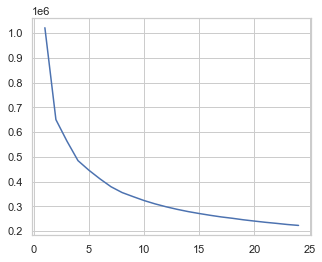

```python
try_elbow(df)
```

**Observations:** Based on the Elbow graph, **either 4, 5, 6 or 7** appear to be the points representing bent elbow. We can further check their Silhouette score to decide number of clusters.

```python
#take a sample
df_sample = df.sample(n=10000)
```

```python
k_vals = [3,4,5,6,7,8]
res = []
for k in k_vals:
    km_model = KMeans(n_clusters=k, max_iter=1000).fit(df_sample)
    res.append((k, km_model.inertia_, cal_silhouette_score(df_sample, km_model.labels_)))
```

```python
res = np.array(res)
res_df = pd.DataFrame({'k': res[:,0], 'wcss': res[:,1], 'silh_score': res[:,2]})
```

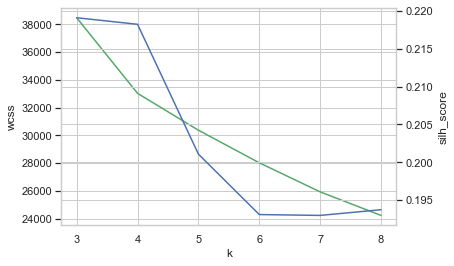

```python
sns.lineplot(y=res_df['wcss'], x=res_df['k'], color="g")
ax2 = plt.twinx()
sns.lineplot(y=res_df['silh_score'], x=res_df['k'], color="b")
```

### Visualizing sample data - PCA and TSNE

```python
visualize_pca(df_sample, ndim=3)
```

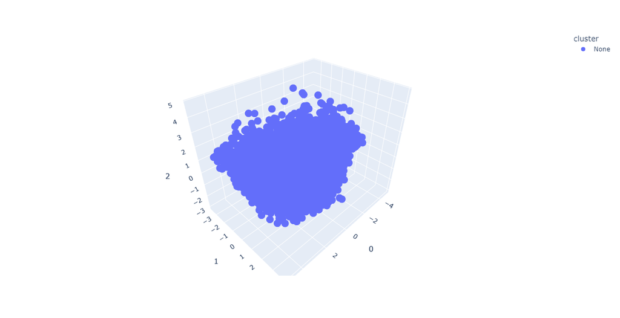

**observation:** 3D PCA visualization isn't revealing any clusters. We can check TSNE visualization next.

```python
visualize_tsne(df_sample, perplexity=70, method='barnes_hut')
```

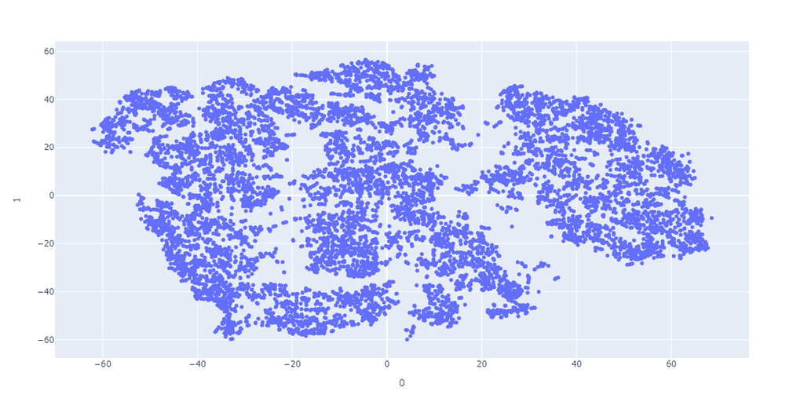

**Observations:** TSNE is revealing a few potential clusters in the data. However they do not appear to be well separated. We will choose k=5 and proceed with kmeans clustering.

### KMeans clustering (k=5)

```python
km_5_sample = KMeans(n_clusters=5, max_iter=1000)
km_5 = KMeans(n_clusters=5, max_iter=1000)

km_vals_sample = km_5_sample.fit_transform(df_sample)
km_vals = km_5.fit_transform(df)
```

### check WCSS and Silhouette scores

```python
silh_score_sample = cal_silhouette_score(df_sample, km_5_sample.labels_)
```

```python
silh_score = cal_silhouette_score(df, km_5.labels_)
```

```python
print(f'For sample: WCSS = {km_5_sample.inertia_}, Silhouette score: {silh_score_sample}')
```

```
For sample: WCSS = 30370.786594598867, Silhouette score: 0.20111120557751513
```

```python
print(f'For full dataset: WCSS = {km_5.inertia_}, Silhouette score: {silh_score}')
```

```
For full dataset: WCSS = 445549.58783793234, Silhouette score: 0.2009007398782452
```

### Visualize clusters - PCA and TSNE

```python
visualize_pca(df_sample, y=km_5_sample.labels_, ndim=3)
```

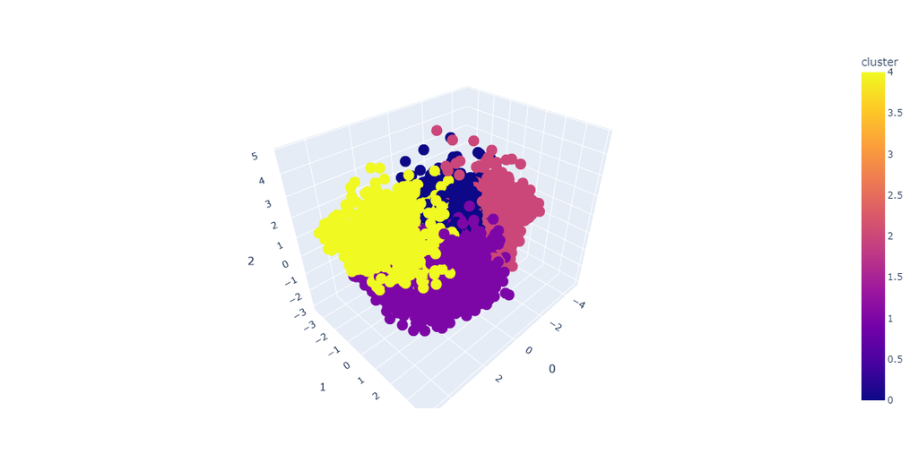

```python
visualize_tsne(df_sample, y=km_5_sample.labels_, perplexity=100, method='barnes_hut')
```

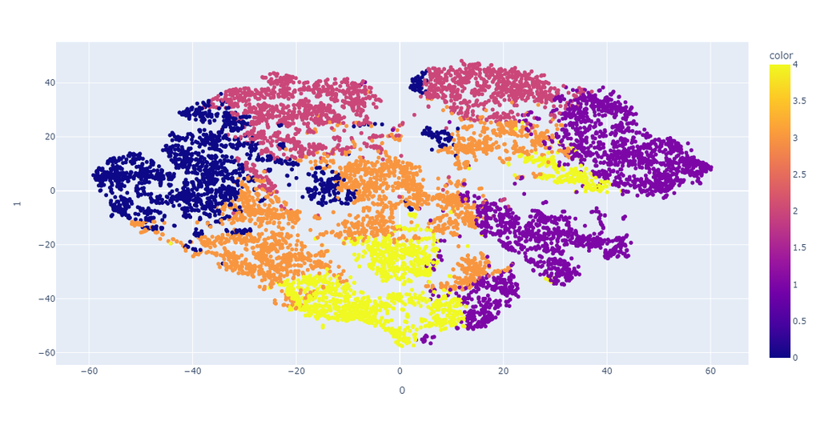

**Observation:** - The PCA visualization shows cohesive clusters although they are not far apart. TSNE graph, on the other hand, doesn't show clusters well. The clusters appear fragmented and containing multiple sub clusters.

## Agglomerative Hierarchical clustering

```python
hc = AgglomerativeClustering(n_clusters=5)
hc.fit(df_sample)
```

```
AgglomerativeClustering(n_clusters=5)
```

### visualize dendrogram (for smaller sample)

```
method = single
```

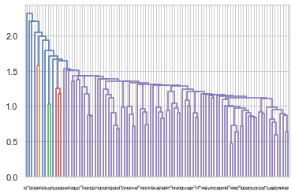

```
method = complete
```

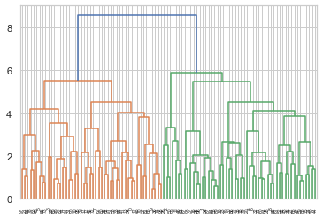

```
method = average
```

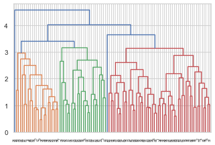

```
method = ward
```

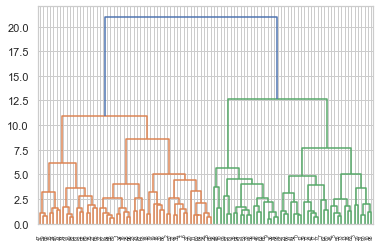

```
method = weighted
```

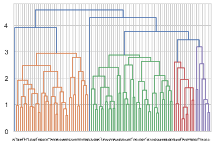

```
method = centroid
```

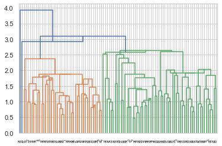

```python
from scipy.cluster import hierarchy

df_sample2 = df.sample(100) #take a smaller sample for dendrogram visualization

methods =  ['single', 'complete', 'average', 'ward', 'weighted', 'centroid' ]

for method in methods:
    Z = hierarchy.linkage(df_sample2, method)
    ret = hierarchy.dendrogram(Z, leaf_rotation=90)
    print(f'method = {method}')
    plt.show()
```

**Observations:** If we look at dendrogram for ward linkage, 4 appears like a reasonable cluster number estimate. However since we have taken a very small sample (100 points), we will continue with k=5.

### Visulize PCA and TSNE

```python
visualize_pca(df_sample, hc.labels_)
```

[figure not shown]

```python
visualize_tsne(df_sample, y=hc.labels_, perplexity=100, method='barnes_hut')
```

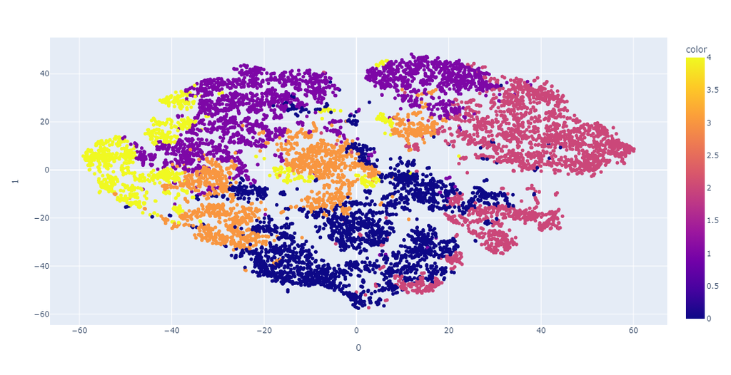

### Silhouette score

```python
#calculate silhouette_score for df_sample clustering
hc_sh_sample_score = cal_silhouette_score(df_sample, hc.labels_)
```

```python
print(f'Agglomerative clustering with sample size {df_sample.shape[0]} => silhoutte score: {hc_sh_sample_score}')
```

```
Agglomerative clustering with sample size 10000 => silhoutte score: 0.1395721201261587
```